# Tugas Pertemuan 2

# Library

```r
library("forecast")
```

```r
library("graphics")
library("TTR")
library("TSA")
library(readxl)
```

# Import Data

```r
data <- read_excel("C:\\Dokumen\\Kuliah IPB\\Semester 5\\Metode Peramalan Deret Waktu\\Praktikum\\File R\\mpdw\\Pertemuan 2\\Data Suhu Rata-Rata Harian Malaysia.xlsx", sheet = "500 Periode")
data1 <- data[301:400,]
```

# Eksplorasi Data

`View()` : menampilkan data dalam bentuk tabel, `str()` : menampilkan struktur data, `dim()` : menampilkan dimensi data

```r
View(data1)
str(data1)
```

```
## tibble [100 × 2] (S3: tbl_df/tbl/data.frame)
##  $ Tanggal  : num [1:100] 301 302 303 304 305 306 307 308 309 310 ...
##  $ Rata_Suhu: num [1:100] 26 26 26.2 25.5 26.4 25.8 24.8 24.5 26.7 26.7 ...
```

```r
dim(data1)
```

```
## [1] 100   2
```

```r
View(data)
str(data)
```

```
## tibble [500 × 2] (S3: tbl_df/tbl/data.frame)
##  $ Tanggal  : num [1:500] 1 2 3 4 5 6 7 8 9 10 ...
##  $ Rata_Suhu: num [1:500] 25.1 24.9 24.5 24.7 25.1 24.7 25.4 26 25.9 25.8 ...
```

```r
dim(data)
```

```
## [1] 500   2
```

Mengubah data agar terbaca sebagai data deret waktu dengan fungsi `ts()` .

```r
data1.ts <- ts(data1$Rata_Suhu)
```

Menampilkan ringkasan data

```r
summary(data1.ts)
```

```
##    Min. 1st Qu.  Median    Mean 3rd Qu.    Max.
##   23.20   25.48   26.05   25.87   26.50   27.20
```

Membuat plot data deret waktu

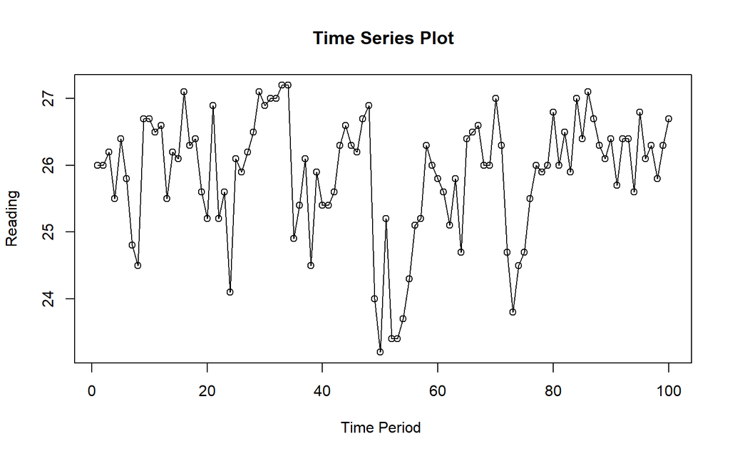

```r
ts.plot(data1.ts, xlab="Time Period ", ylab="Reading",
        main = "Time Series Plot")
points(data1.ts)
```

```r
#menyimpan plot
dev.copy(png, "plot_data1.png")
```

```r
dev.off()
```

# Moving Average

## Pembagian Data

Pembagian data latih dan data uji dilakukan dengan perbandingan 80% data latih dan 20% data uji.

```r
# hitung jumlah data
n <- nrow(data1)

# tentukan batas 80%
n_train <- floor(0.8 * n)

# bagi data
training_ma <- data1[1:n_train, ]
testing_ma  <- data1[(n_train+1):n, ]

# ubah ke time series
train_ma.ts <- ts(training_ma$Rata_Suhu)
test_ma.ts  <- ts(testing_ma$Rata_Suhu)
```

Eksplorasi data dilakukan pada keseluruhan data, data latih serta data uji menggunakan plot data deret waktu.

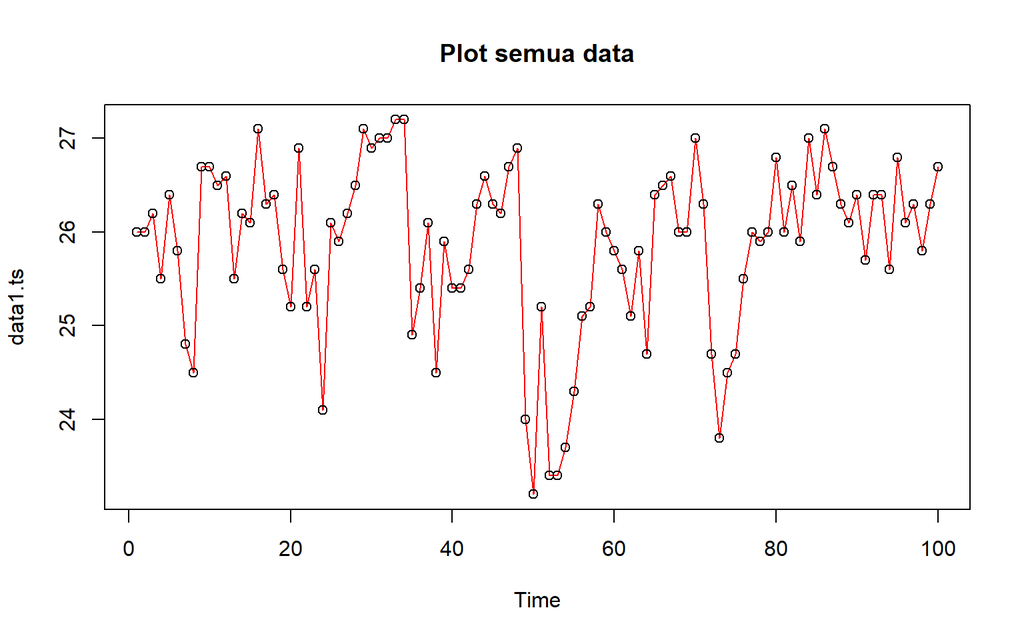

```r
#eksplorasi keseluruhan data
plot(data1.ts, col="red",main="Plot semua data")
points(data1.ts)
```

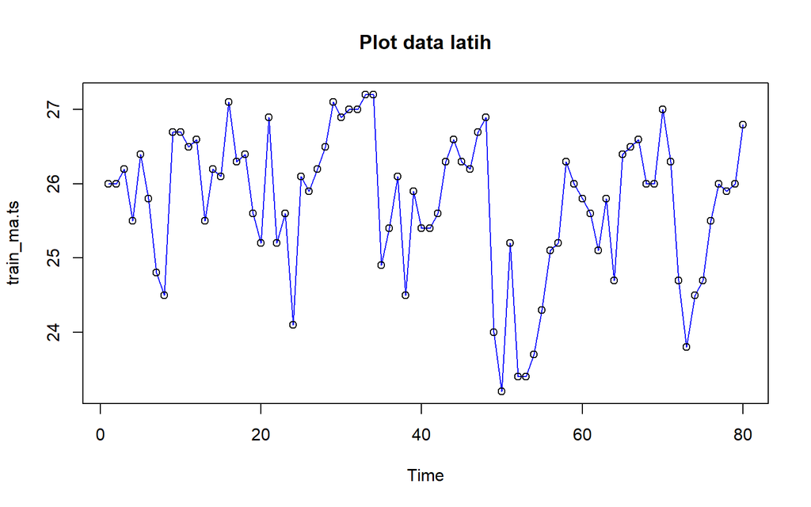

```r
#eksplorasi data latih
plot(train_ma.ts, col="blue",main="Plot data latih")
points(train_ma.ts)
```

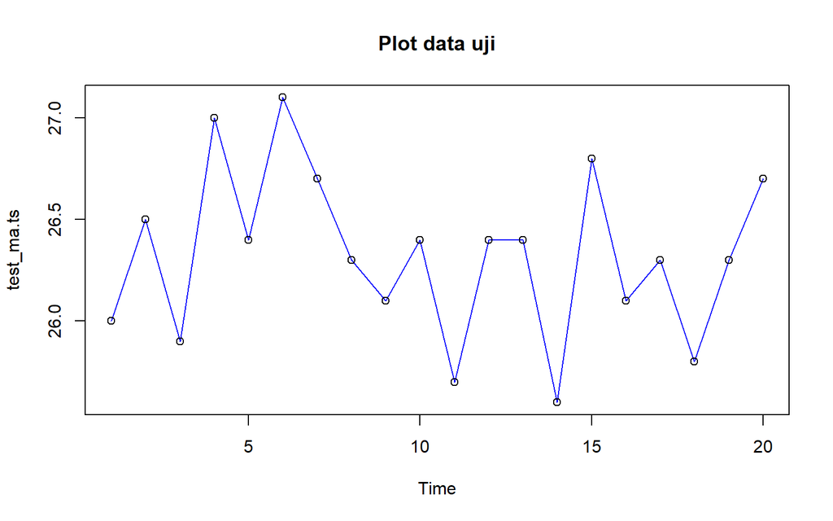

```r
#eksplorasi data uji
plot(test_ma.ts, col="blue",main="Plot data uji")
points(test_ma.ts)
```

Eksplorasi data juga dapat dilakukan menggunakan package `ggplot2` dengan terlebih dahulu memanggil library *package* `ggplot2`.

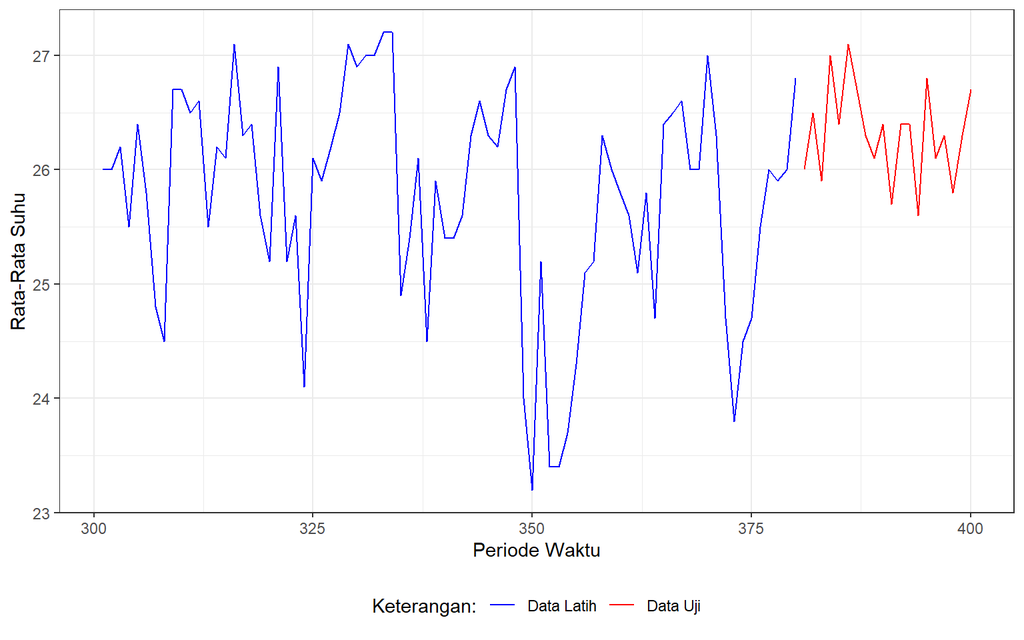

```r
library(ggplot2)
ggplot() +
  geom_line(data = training_ma, aes(x = Tanggal, y = Rata_Suhu, col = "Data Latih")) +
  geom_line(data = testing_ma, aes(x = Tanggal, y = Rata_Suhu, col = "Data Uji")) +
  labs(x = "Periode Waktu", y = "Rata-Rata Suhu", color = "Legend") +
   scale_colour_manual(name="Keterangan:", breaks = c("Data Latih", "Data Uji"),
                      values = c("blue", "red")) +
  theme_bw() + theme(legend.position = "bottom",
                     plot.caption = element_text(hjust=0.5, size=12))
```

## Single Moving Average (SMA)

Ide dasar dari Single Moving Average (SMA) adalah data suatu periode dipengaruhi oleh data periode sebelumnya. Metode pemulusan ini cocok digunakan untuk pola data stasioner atau konstan. Prinsip dasar metode pemulusan ini adalah data pemulusan pada periode ke-t merupakan rata rata dari m buah data pada periode ke-t hingga periode ke (t-m+1).

$$S_t = \frac{1}{m} \sum_{i=t-m+1}^{t} X_i$$
$$S_t = \frac{1}{m}
\sum_{i=t-m+1}^{t} X_i$$

Data pemulusan pada periode ke-t selanjutnya digunakan sebagai nilai peramalan pada periode ke t+1.

$$F_t = S_{t-1}, F_{n,h} =
S_n$$

Pemulusan menggunakan metode SMA dilakukan dengan fungsi `SMA()`. Dalam hal ini akan dilakukan pemulusan dengan parameter `m=4`.

```r
data.sma<-SMA(train_ma.ts, n=4)
data.sma
```

```
## Time Series:
## Start = 1
## End = 80
## Frequency = 1
##  [1]     NA     NA     NA 25.925 26.025 25.975 25.625 25.375 25.450 25.675
## [11] 26.100 26.625 26.325 26.200 26.100 26.225 26.425 26.475 26.350 25.875
## [21] 26.025 25.725 25.725 25.450 25.250 25.425 25.575 26.175 26.425 26.675
## [31] 26.875 27.000 27.025 27.100 26.575 26.175 25.900 25.225 25.475 25.475
## [41] 25.300 25.575 25.675 25.975 26.200 26.350 26.450 26.525 25.950 25.200
## [51] 24.825 23.950 23.800 23.925 23.700 24.125 24.575 25.225 25.650 25.825
## [61] 25.925 25.625 25.575 25.300 25.500 25.850 26.050 26.375 26.275 26.400
## [71] 26.325 26.000 25.450 24.825 24.425 24.625 25.175 25.525 25.850 26.175
```

Data pemulusan pada periode ke-t selanjutnya digunakan sebagai nilai peramalan pada periode ke t+1 sehingga hasil peramalan 1 periode kedepan adalah sebagai berikut.

```r
data.ramal<-c(NA,data.sma)
data.ramal #forecast 1 periode ke depan
```

```
##  [1]     NA     NA     NA     NA 25.925 26.025 25.975 25.625 25.375 25.450
## [11] 25.675 26.100 26.625 26.325 26.200 26.100 26.225 26.425 26.475 26.350
## [21] 25.875 26.025 25.725 25.725 25.450 25.250 25.425 25.575 26.175 26.425
## [31] 26.675 26.875 27.000 27.025 27.100 26.575 26.175 25.900 25.225 25.475
## [41] 25.475 25.300 25.575 25.675 25.975 26.200 26.350 26.450 26.525 25.950
## [51] 25.200 24.825 23.950 23.800 23.925 23.700 24.125 24.575 25.225 25.650
## [61] 25.825 25.925 25.625 25.575 25.300 25.500 25.850 26.050 26.375 26.275
## [71] 26.400 26.325 26.000 25.450 24.825 24.425 24.625 25.175 25.525 25.850
## [81] 26.175
```

```r
data.gab<-cbind(
  aktual=c(data1.ts),
  pemulusan=c(data.sma,rep(NA,24)),
  ramalan=c(data.ramal,rep(data.ramal[length(data.ramal)],23)))
data.gab #forecast 24 periode ke depan
```

```
##        aktual pemulusan ramalan
##   [1,]   26.0        NA      NA
##   [2,]   26.0        NA      NA
##   [3,]   26.2        NA      NA
##   [4,]   25.5    25.925      NA
##   [5,]   26.4    26.025  25.925
##   [6,]   25.8    25.975  26.025
##   [7,]   24.8    25.625  25.975
##   [8,]   24.5    25.375  25.625
##   [9,]   26.7    25.450  25.375
##  [10,]   26.7    25.675  25.450
##  [11,]   26.5    26.100  25.675
##  [12,]   26.6    26.625  26.100
##  [13,]   25.5    26.325  26.625
##  [14,]   26.2    26.200  26.325
```

[output cut: 90 more lines]

Adapun plot data deret waktu dari hasil peramalan yang dilakukan adalah sebagai berikut.

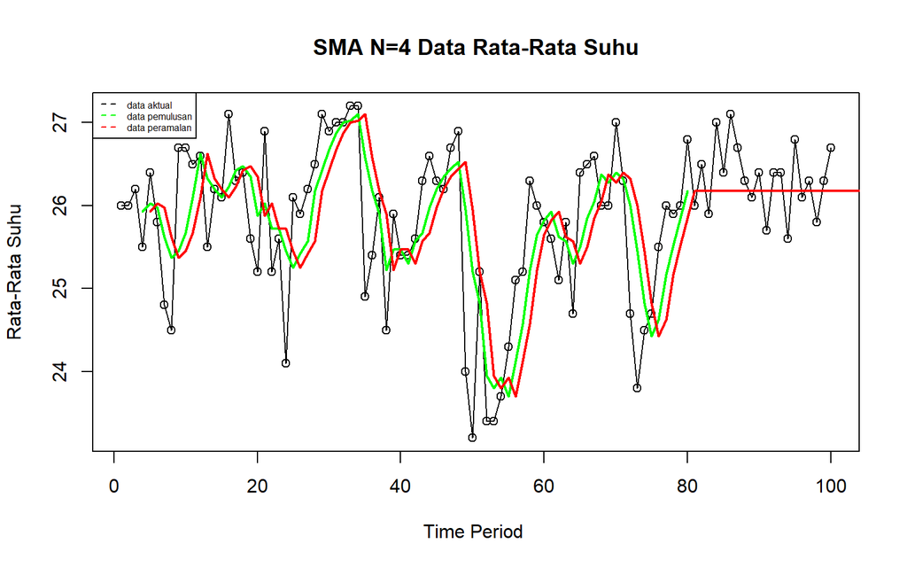

```r
ts.plot(data1.ts, xlab="Time Period ", ylab="Rata-Rata Suhu", main= "SMA N=4 Data Rata-Rata Suhu")
points(data1.ts)
lines(data.gab[,2],col="green",lwd=2)
lines(data.gab[,3],col="red",lwd=2)
legend("topleft",c("data aktual","data pemulusan","data peramalan"), lty=8, col=c("black","green","red"), cex=0.5)
```

Selanjutnya perhitungan akurasi dilakukan dengan ukuran akurasi *Sum Squares Error* (SSE), *Mean Square Error* (MSE) dan *Mean Absolute Percentage Error* (MAPE). Perhitungan akurasi dilakukan baik pada data latih maupun pada data uji.

$$SSE = \sum_{t=1}^{n} (y_t -
\hat{y}_t)^2$$

$$MSE = \frac{1}{n} \sum_{t=1}^{n} (y_t -
\hat{y}_t)^2$$

$$MAPE = \frac{1}{n} \sum_{t=1}^{n}
\left|\frac{y_t - \hat{y}_t}{y_t}\right| * 100$$

### Akurasi Data Latih

```r
#Menghitung nilai keakuratan data latih
error_train.sma = train_ma.ts-data.ramal[1:length(train_ma.ts)]

SSE_train.sma = sum(error_train.sma[5:length(train_ma.ts)]^2)
MSE_train.sma = mean(error_train.sma[5:length(train_ma.ts)]^2)
MAPE_train.sma = mean(abs((error_train.sma[5:length(train_ma.ts)]/train_ma.ts[5:length(train_ma.ts)])*100))

akurasi_train.sma <- matrix(c(SSE_train.sma, MSE_train.sma, MAPE_train.sma))
row.names(akurasi_train.sma)<- c("SSE", "MSE", "MAPE")
colnames(akurasi_train.sma) <- c("Akurasi m = 4")
akurasi_train.sma
```

```
##      Akurasi m = 4
## SSE     71.2875000
## MSE      0.9379934
## MAPE     2.9829869
```

### Akurasi Data Uji

```r
#Menghitung nilai keakuratan data uji
error_test.sma = test_ma.ts-data.gab[81:100,3]

SSE_test.sma = sum(error_test.sma^2)
MSE_test.sma = mean(error_test.sma^2)
MAPE_test.sma = mean(abs((error_test.sma/test_ma.ts*100)))

akurasi_test.sma <- matrix(c(SSE_test.sma, MSE_test.sma, MAPE_test.sma))
row.names(akurasi_test.sma)<- c("SSE", "MSE", "MAPE")
colnames(akurasi_test.sma) <- c("Akurasi m = 4")
akurasi_test.sma
```

```
##      Akurasi m = 4
## SSE       3.647500
## MSE       0.182375
## MAPE      1.332614
```

## Double Moving Average (DMA)

Metode pemulusan Double Moving Average (DMA) pada dasarnya mirip dengan SMA. Namun demikian, metode ini lebih cocok digunakan untuk pola data trend. Proses pemulusan dengan rata rata dalam metode ini dilakukan sebanyak 2 kali.

- **Tahap I:**

$$S_{1,t} = \frac{1}{m} \sum_{i=t-m+1}^{t}
X_i$$

- **Tahap II:**

$$S_{2,t} = \frac{1}{m} \sum_{i=t-m+1}^{t}
S_{1,i}$$

Forecast $h$ langkah ke depan dihitung dengan:

$$F_{2,t,t+h} = A_t + B_t
\,(h)$$

dengan komponen level ($A_t$) dan tren ($B_t$):

$$A_t = 2S_{1,t} - S_{2,t}
\qquad\text{dan}\qquad
B_t = \frac{2}{m-1}\,\big(S_{1,t} - S_{2,t}\big)$$

```r
dma <- SMA(data.sma, n = 4)
At <- 2*data.sma - dma
Bt <- 2/(4-1)*(data.sma - dma)
data.dma<- At+Bt
data.ramal2<- c(NA, data.dma)

t = 1:24
f = c()

for (i in t) {
  f[i] = At[length(At)] + Bt[length(Bt)]*(i)
}

data.gab2 <- cbind(aktual = c(data1.ts),
                   pemulusan1 = c(data.sma,rep(NA,24)),
                   pemulusan2 = c(dma, rep(NA,24)),
                   At = c(At, rep(NA,24)),
                   Bt = c(Bt,rep(NA,24)),
                   ramalan = c(data.ramal2, f[-1]))
data.gab2
```

```
##        aktual pemulusan1 pemulusan2       At            Bt  ramalan
##   [1,]   26.0         NA         NA       NA            NA       NA
##   [2,]   26.0         NA         NA       NA            NA       NA
##   [3,]   26.2         NA         NA       NA            NA       NA
##   [4,]   25.5     25.925         NA       NA            NA       NA
##   [5,]   26.4     26.025         NA       NA            NA       NA
##   [6,]   25.8     25.975         NA       NA            NA       NA
##   [7,]   24.8     25.625   25.88750 25.36250 -1.750000e-01       NA
##   [8,]   24.5     25.375   25.75000 25.00000 -2.500000e-01 25.18750
##   [9,]   26.7     25.450   25.60625 25.29375 -1.041667e-01 24.75000
##  [10,]   26.7     25.675   25.53125 25.81875  9.583333e-02 25.18958
##  [11,]   26.5     26.100   25.65000 26.55000  3.000000e-01 25.91458
##  [12,]   26.6     26.625   25.96250 27.28750  4.416667e-01 26.85000
##  [13,]   25.5     26.325   26.18125 26.46875  9.583333e-02 27.72917
##  [14,]   26.2     26.200   26.31250 26.08750 -7.500000e-02 26.56458
```

[output cut: 90 more lines]

Hasil pemulusan menggunakan metode DMA divisualisasikan sebagai berikut

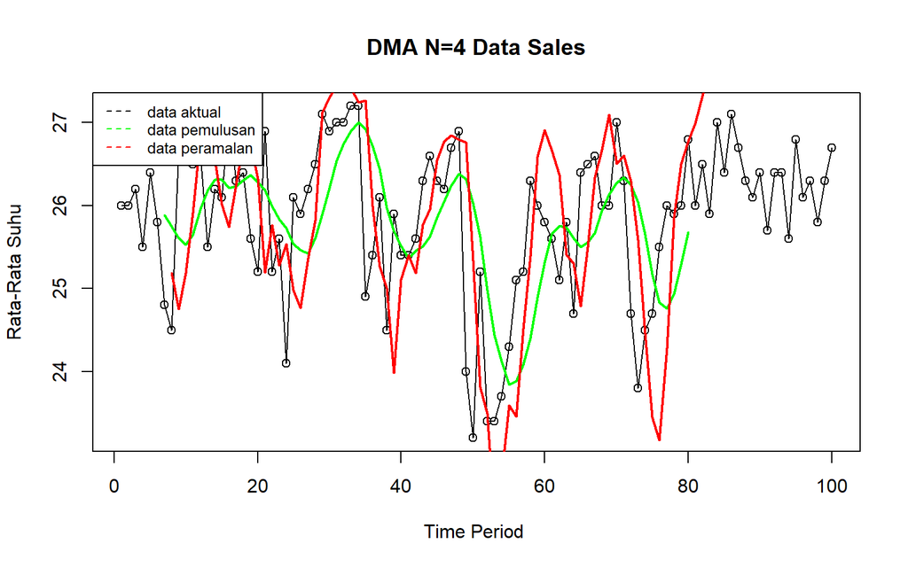

```r
ts.plot(data1.ts, xlab="Time Period ", ylab="Rata-Rata Suhu", main= "DMA N=4 Data Sales")
points(data1.ts)
lines(data.gab2[,3],col="green",lwd=2)
lines(data.gab2[,6],col="red",lwd=2)
legend("topleft",c("data aktual","data pemulusan","data peramalan"), lty=8, col=c("black","green","red"), cex=0.8)
```

Selanjutnya perhitungan akurasi dilakukan baik pada data latih maupun data uji. Perhitungan akurasi dilakukan dengan ukuran akurasi SSE, MSE dan MAPE.

### Akurasi Data Latih

```r
#Menghitung nilai keakuratan data latih
error_train.dma = train_ma.ts-data.ramal2[1:length(train_ma.ts)]

SSE_train.dma = sum(error_train.dma[8:length(train_ma.ts)]^2)
MSE_train.dma = mean(error_train.dma[8:length(train_ma.ts)]^2)
MAPE_train.dma = mean(abs((error_train.dma[8:length(train_ma.ts)]/train_ma.ts[8:length(train_ma.ts)])*100))

akurasi_train.dma <- matrix(c(SSE_train.dma, MSE_train.dma, MAPE_train.dma))
row.names(akurasi_train.dma)<- c("SSE", "MSE", "MAPE")
colnames(akurasi_train.dma) <- c("Akurasi m = 4")
akurasi_train.dma
```

```
##      Akurasi m = 4
## SSE      85.544188
## MSE       1.171838
## MAPE      3.361586
```

Perhitungan akurasi pada data latih menggunakan nilai MAPE menghasilkan nilai MAPE yang kurang dari 10% sehingga dikategorikan sangat baik. Selanjutnya, perhitungan nilai akurasi dilakukan pada data uji.

### Akurasi Data Uji

```r
#Menghitung nilai keakuratan data uji
error_test.dma = test_ma.ts-data.gab2[81:100,6]
SSE_test.dma = sum(error_test.dma^2)
MSE_test.dma = mean(error_test.dma^2)
MAPE_test.dma = mean(abs((error_test.dma/test_ma.ts*100)))

akurasi_test.dma <- matrix(c(SSE_test.dma, MSE_test.dma, MAPE_test.dma))
row.names(akurasi_test.dma)<- c("SSE", "MSE", "MAPE")
colnames(akurasi_test.dma) <- c("Akurasi m = 4")
akurasi_test.dma
```

```
##      Akurasi m = 4
## SSE      368.56030
## MSE       18.42801
## MAPE      14.47743
```

# Exponential Smoothing

Metode Exponential Smoothing merupakan metode pemulusan deret waktu dengan memberikan bobot yang menurun secara eksponensial pada data historis, di mana nilai terbaru mendapat bobot lebih besar dibanding nilai yang lebih lama. Metode ini menggunakan satu atau lebih parameter pemulusan yang secara langsung menentukan besar kecilnya bobot setiap pengamatan. Pemilihan parameter yang tepat akan sangat berpengaruh terhadap hasil ramalan. Secara umum, Exponential Smoothing dibedakan menjadi dua jenis, yaitu model tunggal (single) yang digunakan untuk data tanpa tren maupun musiman, serta model ganda (double) yang mampu menangkap adanya tren pada data.

## Pembagian Data

Pembagian data latih dan data uji dilakukan dengan perbandingan 80% data latih dan 20% data uji.

```r
# jumlah baris data
n <- nrow(data1)

# hitung batas 80%
n_train <- floor(0.8 * n)

# bagi data
training <- data1[1:n_train, ]
testing  <- data1[(n_train+1):n, ]

# ubah ke time series
train.ts <- ts(training$Rata_Suhu)
test.ts  <- ts(testing$Rata_Suhu)
```

## Eksplorasi

Eksplorasi dilakukan dengan membuat plot data deret waktu untuk keseluruhan data, data latih, dan data uji.

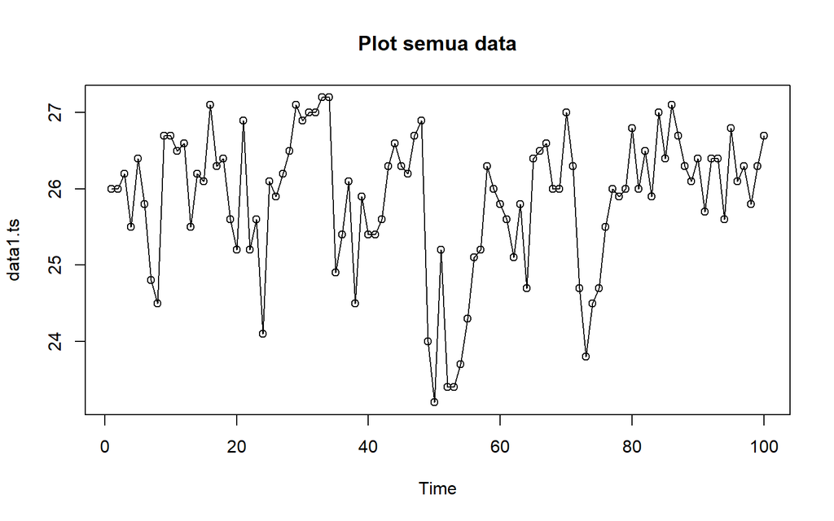

```r
#eksplorasi data
plot(data1.ts, col="black",main="Plot semua data")
points(data1.ts)
```

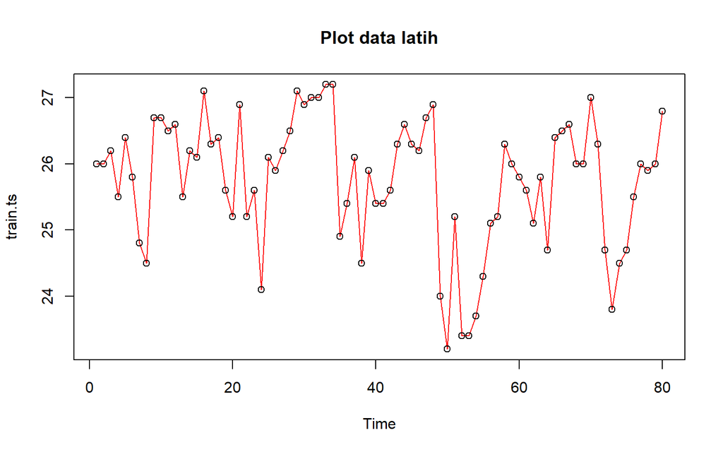

```r
plot(train.ts, col="red",main="Plot data latih")
points(train.ts)
```

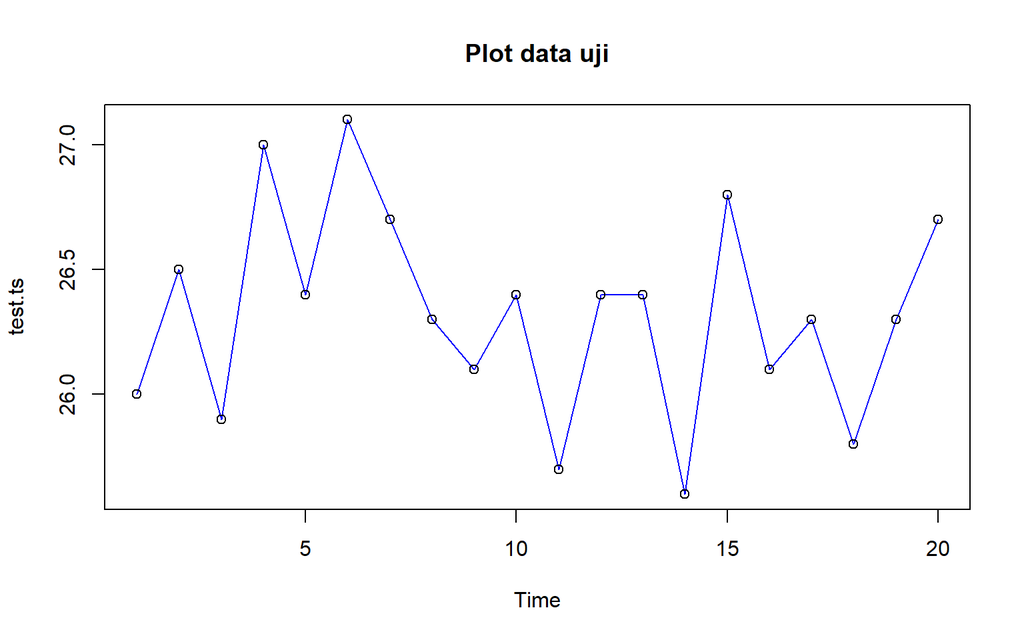

```r
plot(test.ts, col="blue",main="Plot data uji")
points(test.ts)
```

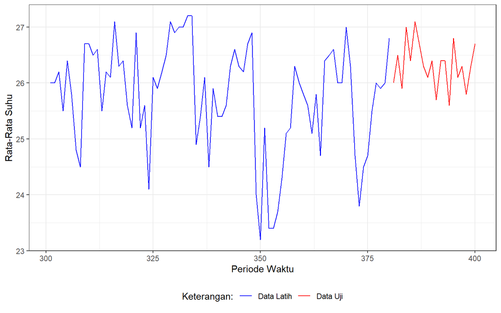

```r
#Eksplorasi dengan GGPLOT
library(ggplot2)
ggplot() +
  geom_line(data = training, aes(x = Tanggal, y = Rata_Suhu, col = "Data Latih")) +
  geom_line(data = testing, aes(x = Tanggal, y = Rata_Suhu, col = "Data Uji")) +
  labs(x = "Periode Waktu", y = "Rata-Rata Suhu", color = "Legend") +
  scale_colour_manual(name="Keterangan:", breaks = c("Data Latih", "Data Uji"),
                      values = c("blue", "red")) +
  theme_bw() + theme(legend.position = "bottom",
                     plot.caption = element_text(hjust=0.5, size=12))
```

## Single Exponential Smoothing

Single Exponential Smoothing (SES) adalah metode peramalan deret waktu yang dikembangkan untuk mengatasi kelemahan Moving Average. Jika pada Moving Average setiap data periode sebelumnya dianggap memiliki bobot yang sama, maka SES memberikan bobot yang semakin mengecil secara eksponensial terhadap data lama, sehingga data terbaru diberi bobot lebih besar.

Single Exponential Smoothing merupakan metode pemulusan yang tepat digunakan untuk data dengan pola stasioner atau konstan.

Nilai pemulusan pada periode ke-t didapat dari persamaan:

$$\tilde{y}_T=\lambda
y_t+(1-\lambda)\tilde{y}_{T-1}$$

Nilai parameter $\lambda$ adalah nilai antara 0 dan 1.

Nilai pemulusan periode ke-t bertindak sebagai nilai ramalan pada periode ke-$(T+\tau)$.

$$\tilde{y}_{T+\tau}(T)=\tilde{y}_T$$

Pemulusan dengan metode SES dapat dilakukan dengan dua fungsi dari *packages* berbeda, yaitu (1) fungsi `ses()` dari *packages* `forecast` dan (2) fungsi `HoltWinters` dari *packages* `stats` .

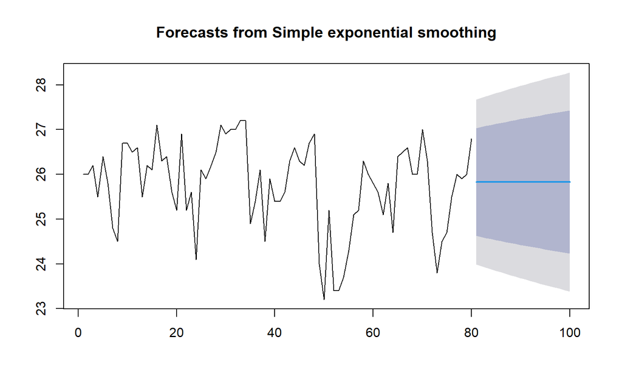

```r
#Cara 1 (fungsi ses)
ses.1 <- ses(train.ts, h = 20, alpha = 0.2)
plot(ses.1)
```

```r
ses.1
```

```
##     Point Forecast    Lo 80    Hi 80    Lo 95    Hi 95
##  81        25.8294 24.62484 27.03397 23.98718 27.67163
##  82        25.8294 24.60098 27.05783 23.95069 27.70811
##  83        25.8294 24.57758 27.08123 23.91490 27.74390
##  84        25.8294 24.55461 27.10420 23.87977 27.77903
##  85        25.8294 24.53204 27.12676 23.84526 27.81354
##  86        25.8294 24.50987 27.14894 23.81134 27.84746
##  87        25.8294 24.48805 27.17075 23.77799 27.88082
##  88        25.8294 24.46659 27.19222 23.74516 27.91365
##  89        25.8294 24.44546 27.21335 23.71284 27.94596
##  90        25.8294 24.42465 27.23416 23.68101 27.97779
##  91        25.8294 24.40414 27.25467 23.64965 28.00916
##  92        25.8294 24.38392 27.27488 23.61873 28.04008
##  93        25.8294 24.36398 27.29482 23.58824 28.07057
##  94        25.8294 24.34431 27.31449 23.55815 28.10065
##  95        25.8294 24.32490 27.33391 23.52846 28.13034
##  96        25.8294 24.30573 27.35307 23.49915 28.15966
##  97        25.8294 24.28680 27.37200 23.47020 28.18861
##  98        25.8294 24.26810 27.39070 23.44160 28.21720
##  99        25.8294 24.24963 27.40918 23.41334 28.24546
## 100        25.8294 24.23136 27.42744 23.38541 28.27339
```

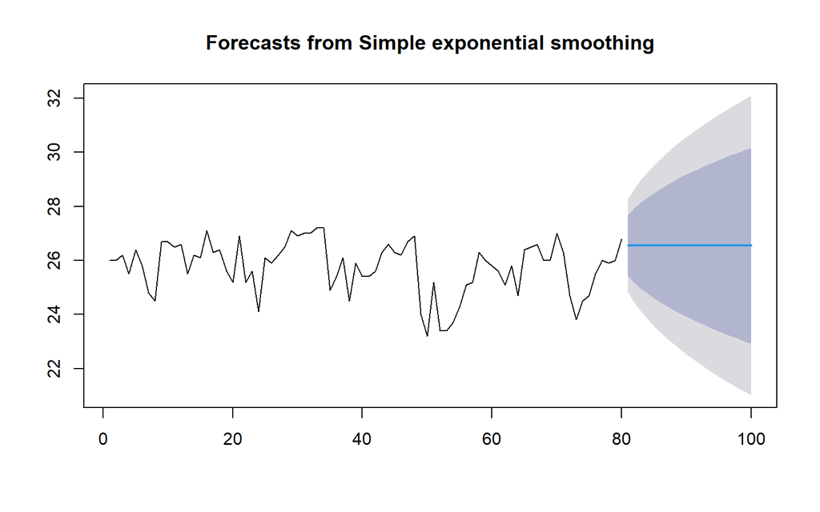

```r
ses.2<- ses(train.ts, h = 20, alpha = 0.7)
plot(ses.2)
```

```r
ses.2
```

```
##     Point Forecast    Lo 80    Hi 80    Lo 95    Hi 95
##  81        26.5475 25.41831 27.67669 24.82056 28.27444
##  82        26.5475 25.16915 27.92585 24.43950 28.65550
##  83        26.5475 24.95859 28.13641 24.11748 28.97752
##  84        26.5475 24.77284 28.32216 23.83340 29.26160
##  85        26.5475 24.60477 28.49023 23.57636 29.51865
##  86        26.5475 24.45013 28.64487 23.33985 29.75515
##  87        26.5475 24.30613 28.78887 23.11962 29.97538
##  88        26.5475 24.17084 28.92416 22.91271 30.18229
##  89        26.5475 24.04284 29.05216 22.71696 30.37804
##  90        26.5475 23.92108 29.17392 22.53073 30.56427
##  91        26.5475 23.80471 29.29029 22.35277 30.74223
##  92        26.5475 23.69309 29.40191 22.18206 30.91294
##  93        26.5475 23.58567 29.50933 22.01777 31.07723
##  94        26.5475 23.48201 29.61299 21.85924 31.23576
##  95        26.5475 23.38175 29.71325 21.70590 31.38910
##  96        26.5475 23.28456 29.81044 21.55726 31.53774
##  97        26.5475 23.19018 29.90482 21.41293 31.68207
##  98        26.5475 23.09839 29.99661 21.27254 31.82246
##  99        26.5475 23.00898 30.08602 21.13580 31.95920
## 100        26.5475 22.92177 30.17323 21.00243 32.09257
```

Pada fungsi `ses()` , terdapat beberapa argumen yang umum digunakan, yaitu

- `y` : nilai data deret waktu
- `alpha` : parameter pemulusan utama (0–1), mengatur bobot data terbaru vs data lama.
- `beta` : parameter pemulusan tren.
- `gamma` : parameter pemulusan musiman.
- `h` : jumlah periode ke depan yang ingin diramalkan (forecast horizon).

Untuk mendapatkan gambar hasil pemulusan pada data latih dengan fungsi `ses()` , perlu digunakan fungsi `autoplot()` dan `autolayer()` dari *library packages* `ggplot2` .

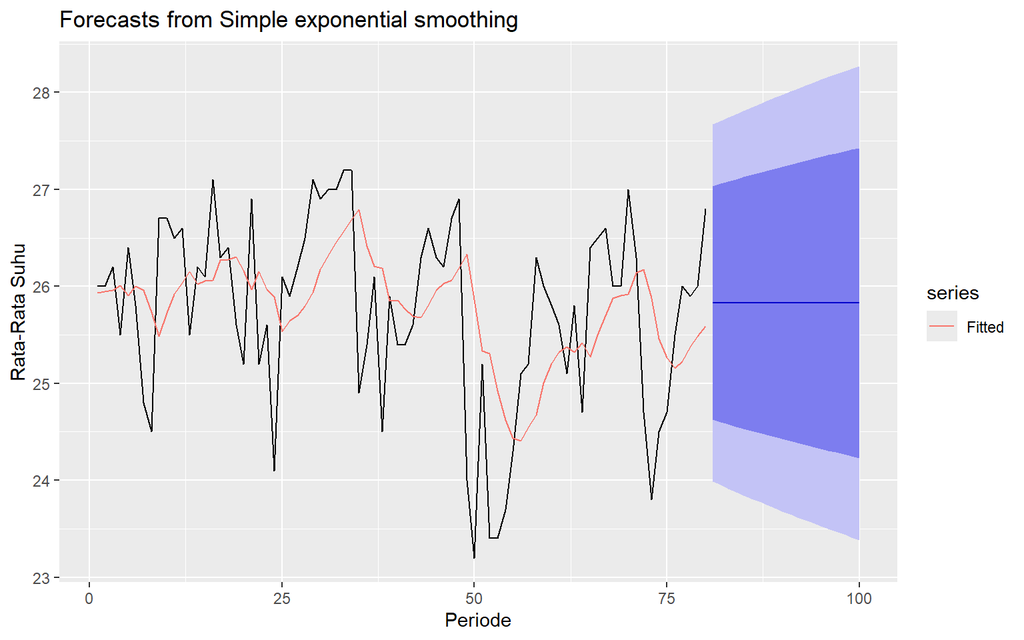

```r
autoplot(ses.1) +
  autolayer(fitted(ses.1), series="Fitted") +
  ylab("Rata-Rata Suhu") + xlab("Periode")
```

Selanjutnya akan digunakan fungsi `HoltWinters()` dengan nilai inisialisasi parameter dan panjang periode peramalan yang sama dengan fungsi `ses()` .

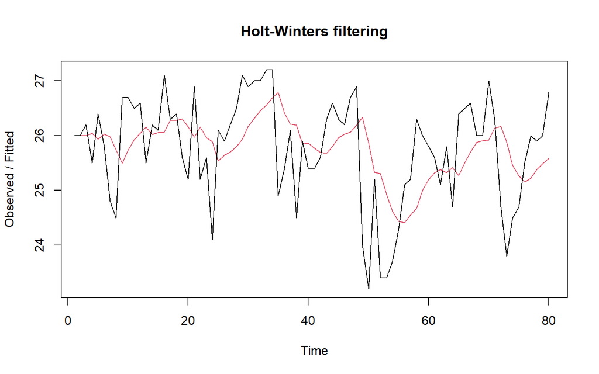

```r
#Cara 2 (fungsi Holtwinter)
ses1<- HoltWinters(train.ts, gamma = FALSE, beta = FALSE, alpha = 0.2)
plot(ses1)
```

```r
#ramalan
ramalan1<- forecast(ses1, h=20)
ramalan1
```

```
##     Point Forecast    Lo 80    Hi 80    Lo 95    Hi 95
##  81        25.8294 24.62481 27.03399 23.98714 27.67167
##  82        25.8294 24.60096 27.05785 23.95066 27.70815
##  83        25.8294 24.57756 27.08125 23.91487 27.74394
##  84        25.8294 24.55458 27.10422 23.87973 27.77907
##  85        25.8294 24.53202 27.12679 23.84522 27.81358
##  86        25.8294 24.50984 27.14897 23.81130 27.84750
##  87        25.8294 24.48803 27.17078 23.77795 27.88086
##  88        25.8294 24.46656 27.19224 23.74512 27.91369
##  89        25.8294 24.44543 27.21337 23.71280 27.94600
##  90        25.8294 24.42462 27.23419 23.68097 27.97783
##  91        25.8294 24.40411 27.25469 23.64961 28.00920
##  92        25.8294 24.38389 27.27491 23.61869 28.04012
##  93        25.8294 24.36395 27.29485 23.58819 28.07061
##  94        25.8294 24.34428 27.31452 23.55811 28.10070
##  95        25.8294 24.32487 27.33394 23.52842 28.13039
##  96        25.8294 24.30570 27.35310 23.49910 28.15970
##  97        25.8294 24.28677 27.37203 23.47015 28.18865
##  98        25.8294 24.26807 27.39073 23.44156 28.21725
##  99        25.8294 24.24960 27.40921 23.41330 28.24551
## 100        25.8294 24.23133 27.42747 23.38536 28.27344
```

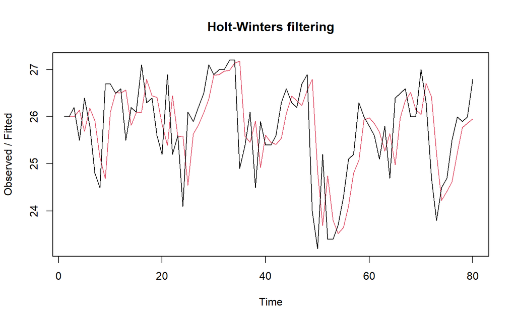

```r
ses2<- HoltWinters(train.ts, gamma = FALSE, beta = FALSE, alpha = 0.7)
plot(ses2)
```

```r
#ramalan
ramalan2<- forecast(ses2, h=20)
ramalan2
```

```
##     Point Forecast    Lo 80    Hi 80    Lo 95    Hi 95
##  81        26.5475 25.41838 27.67662 24.82067 28.27433
##  82        26.5475 25.16924 27.92576 24.43963 28.65537
##  83        26.5475 24.95869 28.13631 24.11763 28.97737
##  84        26.5475 24.77296 28.32204 23.83357 29.26143
##  85        26.5475 24.60490 28.49010 23.57654 29.51846
##  86        26.5475 24.45026 28.64474 23.34005 29.75495
##  87        26.5475 24.30627 28.78873 23.11983 29.97517
##  88        26.5475 24.17099 28.92401 22.91294 30.18206
##  89        26.5475 24.04300 29.05200 22.71720 30.37780
##  90        26.5475 23.92124 29.17376 22.53099 30.56401
##  91        26.5475 23.80489 29.29011 22.35304 30.74196
##  92        26.5475 23.69327 29.40173 22.18233 30.91267
##  93        26.5475 23.58586 29.50914 22.01806 31.07694
##  94        26.5475 23.48221 29.61279 21.85954 31.23546
##  95        26.5475 23.38195 29.71305 21.70620 31.38880
##  96        26.5475 23.28477 29.81023 21.55758 31.53742
##  97        26.5475 23.19040 29.90460 21.41326 31.68174
##  98        26.5475 23.09861 29.99639 21.27288 31.82212
##  99        26.5475 23.00921 30.08580 21.13614 31.95886
## 100        26.5475 22.92200 30.17300 21.00278 32.09222
```

Fungsi `HoltWinters` memiliki argumen yang sama dengan fungsi `ses()` . Argumen-argumen kedua fungsi dapat dilihat lebih lanjut dengan `?ses()` atau `?HoltWinters` .

Nilai parameter $\alpha$ dari kedua fungsi dapat dioptimalkan menyesuaikan dari *error*-nya paling minimumnya. Caranya adalah dengan membuat parameter $\alpha =$ `NULL` .

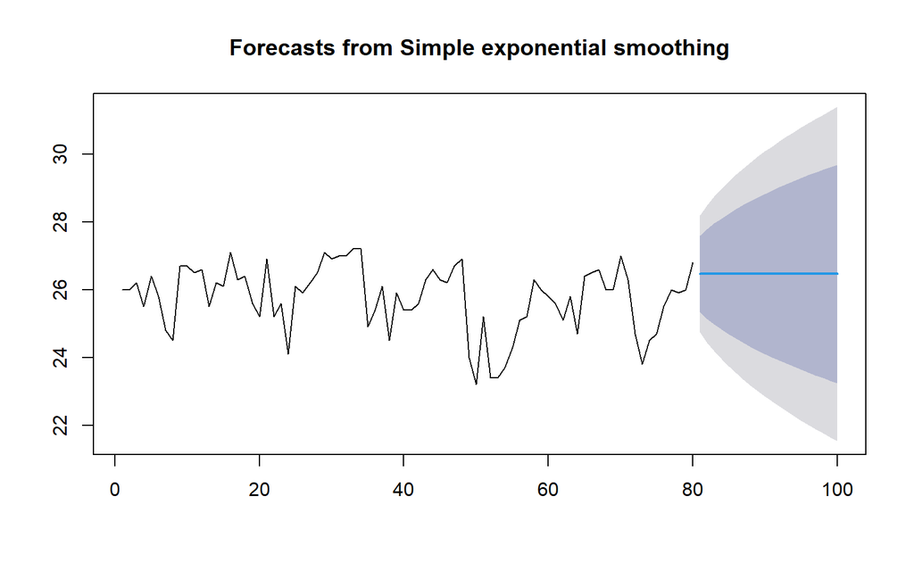

```r
#SES
ses.opt <- ses(train.ts, h = 20, alpha = NULL)
plot(ses.opt)
```

```r
ses.opt
```

```
##     Point Forecast    Lo 80    Hi 80    Lo 95    Hi 95
##  81       26.46463 25.33886 27.59039 24.74292 28.18633
##  82       26.46463 25.14285 27.78640 24.44315 28.48610
##  83       26.46463 24.97237 27.95688 24.18242 28.74683
##  84       26.46463 24.81947 28.10979 23.94857 28.98068
##  85       26.46463 24.67961 28.24964 23.73468 29.19458
##  86       26.46463 24.54994 28.37931 23.53636 29.39289
##  87       26.46463 24.42851 28.50074 23.35066 29.57860
##  88       26.46463 24.31393 28.61532 23.17542 29.75383
##  89       26.46463 24.20515 28.72410 23.00905 29.92020
##  90       26.46463 24.10137 28.82788 22.85034 30.07891
##  91       26.46463 24.00196 28.92729 22.69831 30.23095
##  92       26.46463 23.90641 29.02284 22.55218 30.37707
##  93       26.46463 23.81431 29.11494 22.41131 30.51794
##  94       26.46463 23.72530 29.20396 22.27518 30.65407
##  95       26.46463 23.63909 29.29016 22.14334 30.78591
##  96       26.46463 23.55543 29.37382 22.01540 30.91385
##  97       26.46463 23.47412 29.45513 21.89104 31.03821
##  98       26.46463 23.39495 29.53430 21.76997 31.15928
##  99       26.46463 23.31778 29.61147 21.65195 31.27731
## 100       26.46463 23.24246 29.68679 21.53675 31.39250
```

```r
#Lamda Optimum Holt Winter
HWopt<- HoltWinters(train.ts, gamma = FALSE, beta = FALSE,alpha = NULL)
HWopt
```

```
## Holt-Winters exponential smoothing without trend and without seasonal component.
##
## Call:
## HoltWinters(x = train.ts, alpha = NULL, beta = FALSE, gamma = FALSE)
##
## Smoothing parameters:
##  alpha: 0.615227
##  beta : FALSE
##  gamma: FALSE
##
## Coefficients:
##      [,1]
## a 26.4646
```

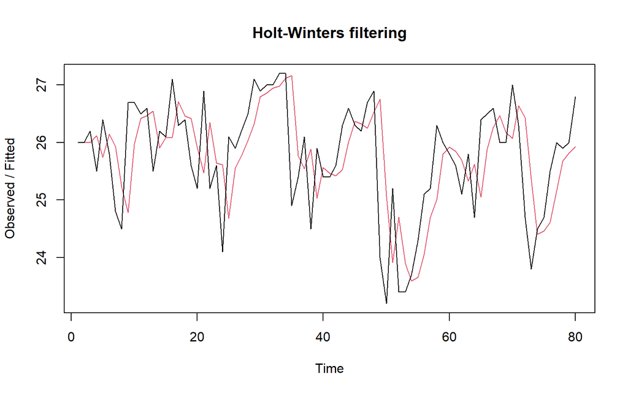

```r
plot(HWopt)
```

```r
#ramalan
ramalanopt<- forecast(HWopt, h=20)
ramalanopt
```

```
##     Point Forecast    Lo 80    Hi 80    Lo 95    Hi 95
##  81        26.4646 25.33890 27.59029 24.74300 28.18620
##  82        26.4646 25.14292 27.78627 24.44327 28.48592
##  83        26.4646 24.97246 27.95673 24.18258 28.74662
##  84        26.4646 24.81957 28.10962 23.94875 28.98044
##  85        26.4646 24.67973 28.24946 23.73489 29.19431
##  86        26.4646 24.55008 28.37911 23.53660 29.39259
##  87        26.4646 24.42867 28.50052 23.35091 29.57828
##  88        26.4646 24.31410 28.61509 23.17569 29.75350
##  89        26.4646 24.20533 28.72386 23.00935 29.91984
##  90        26.4646 24.10157 28.82763 22.85065 30.07854
##  91        26.4646 24.00217 28.92702 22.69864 30.23055
##  92        26.4646 23.90663 29.02256 22.55253 30.37667
##  93        26.4646 23.81454 29.11466 22.41168 30.51751
##  94        26.4646 23.72553 29.20366 22.27556 30.65363
##  95        26.4646 23.63934 29.28986 22.14373 30.78546
##  96        26.4646 23.55569 29.37350 22.01581 30.91338
##  97        26.4646 23.47438 29.45481 21.89146 31.03773
##  98        26.4646 23.39523 29.53396 21.77041 31.15879
##  99        26.4646 23.31807 29.61112 21.65240 31.27680
## 100        26.4646 23.24275 29.68644 21.53721 31.39198
```

Setelah dilakukan peramalan, akan dilakukan perhitungan keakuratan hasil peramalan. Perhitungan akurasi ini dilakukan baik pada data latih dan data uji.

### Akurasi Data Latih

Perhitungan akurasi data dapat dilakukan dengan cara langsung maupun manual. Secara langsung, nilai akurasi dapat diambil dari objek yang tersimpan pada hasil SES, yaitu *sum of squared errors* (SSE). Nilai akurasi lain dapat dihitung pula dari nilai SSE tersebut.

```r
#Keakuratan Metode
#Pada data training

# SES dengan alpha = 0.2
SSE1<-ses1$SSE
MSE1<-ses1$SSE/length(train.ts)
RMSE1<-sqrt(MSE1)

akurasi1 <- matrix(c(SSE1,MSE1,RMSE1))
row.names(akurasi1)<- c("SSE", "MSE", "RMSE")
colnames(akurasi1) <- c("Akurasi lamda=0.2")
akurasi1
```

```
##      Akurasi lamda=0.2
## SSE         68.9223229
## MSE          0.8615290
## RMSE         0.9281859
```

```r
# SES dengan alpha = 0.7
SSE2<-ses2$SSE
MSE2<-ses2$SSE/length(train.ts)
RMSE2<-sqrt(MSE2)

akurasi2 <- matrix(c(SSE2,MSE2,RMSE2))
row.names(akurasi2)<- c("SSE", "MSE", "RMSE")
colnames(akurasi2) <- c("Akurasi lamda=0.7")
akurasi2
```

```
##      Akurasi lamda=0.7
## SSE         60.5556362
## MSE          0.7569455
## RMSE         0.8700261
```

```r
#Cara Manual
# Alpha = 0.2
fitted1<-ramalan1$fitted
sisaan1<-ramalan1$residuals
head(sisaan1)
```

```
## Time Series:
## Start = 1
## End = 6
## Frequency = 1
## [1]      NA  0.0000  0.2000 -0.5400  0.4680 -0.2256
```

```r
resid1<-training$Rata_Suhu-ramalan1$fitted
head(resid1)
```

```
## Time Series:
## Start = 1
## End = 6
## Frequency = 1
## [1]      NA  0.0000  0.2000 -0.5400  0.4680 -0.2256
```

```r
SSE.1=sum(sisaan1[2:length(train.ts)]^2)
SSE.1
```

```
## [1] 68.92232
```

```r
MSE.1 = SSE.1/length(train.ts)
MSE.1
```

```
## [1] 0.861529
```

```r
MAPE.1 = sum(abs(sisaan1[2:length(train.ts)]/train.ts[2:length(train.ts)])*
               100)/length(train.ts)
MAPE.1
```

```
## [1] 2.910504
```

```r
akurasi.1 <- matrix(c(SSE.1,MSE.1,MAPE.1))
row.names(akurasi.1)<- c("SSE", "MSE", "MAPE")
colnames(akurasi.1) <- c("Akurasi lamda=0.2")
akurasi.1
```

```
##      Akurasi lamda=0.2
## SSE          68.922323
## MSE           0.861529
## MAPE          2.910504
```

```r
# Alpha = 0.7
fitted2<-ramalan2$fitted
sisaan2<-ramalan2$residuals
head(sisaan2)
```

```
## Time Series:
## Start = 1
## End = 6
## Frequency = 1
## [1]      NA  0.0000  0.2000 -0.6400  0.7080 -0.3876
```

```r
resid2<-training$Rata_Suhu-ramalan2$fitted
head(resid2)
```

```
## Time Series:
## Start = 1
## End = 6
## Frequency = 1
## [1]      NA  0.0000  0.2000 -0.6400  0.7080 -0.3876
```

```r
SSE.2=sum(sisaan2[2:length(train.ts)]^2)
SSE.2
```

```
## [1] 60.55564
```

```r
MSE.2 = SSE.2/length(train.ts)
MSE.2
```

```
## [1] 0.7569455
```

```r
MAPE.2 = sum(abs(sisaan2[2:length(train.ts)]/train.ts[2:length(train.ts)])*
               100)/length(train.ts)
MAPE.2
```

```
## [1] 2.541977
```

```r
akurasi.2 <- matrix(c(SSE.2,MSE.2,MAPE.2))
row.names(akurasi.2)<- c("SSE", "MSE", "MAPE")
colnames(akurasi.2) <- c("Akurasi lamda=0.7")
akurasi.2
```

```
##      Akurasi lamda=0.7
## SSE         60.5556362
## MSE          0.7569455
## MAPE         2.5419768
```

Berdasarkan nilai SSE, MSE, RMSE, dan MAPE di antara kedua parameter, nilai parameter $\lambda=0,7$ menghasilkan akurasi yang lebih baik dibanding $\lambda=0,2$ . Hal ini dilihat dari nilai masing-masing ukuran akurasi yang lebih kecil. Berdasarkan nilai MAPE-nya, hasil ini dapat dikategorikan sebagai peramalan sangat baik.

### Akurasi Data Uji

Akurasi data uji dapat dihitung dengan cara yang hampir sama dengan perhitungan akurasi data latih.

```r
# jumlah observasi uji
n_test <- nrow(testing)

# error (ramalan - aktual), samakan panjang dan tipe numeric
e1   <- as.numeric(ramalan1$mean)[1:n_test] - as.numeric(testing$Rata_Suhu)
e2   <- as.numeric(ramalan2$mean)[1:n_test] - as.numeric(testing$Rata_Suhu)
eopt <- as.numeric(ramalanopt$mean)[1:n_test] - as.numeric(testing$Rata_Suhu)

# SSE / MSE / RMSE untuk masing-masing model (abaikan NA)
SSEtesting1  <- sum(e1^2,  na.rm = TRUE)
MSEtesting1  <- mean(e1^2, na.rm = TRUE)
RMSEtesting1 <- sqrt(MSEtesting1)

SSEtesting2  <- sum(e2^2,  na.rm = TRUE)
MSEtesting2  <- mean(e2^2, na.rm = TRUE)
RMSEtesting2 <- sqrt(MSEtesting2)

SSEtestingopt  <- sum(eopt^2,  na.rm = TRUE)
MSEtestingopt  <- mean(eopt^2, na.rm = TRUE)
RMSEtestingopt <- sqrt(MSEtestingopt)

# Tabel ringkas
akurasitesting_SSE <- matrix(c(SSEtesting1, SSEtesting2, SSEtestingopt),
                             nrow = 3,
                             dimnames = list(c("SSE1","SSE2","SSEopt"), "Nilai"))
akurasitesting_MSE <- matrix(c(MSEtesting1, MSEtesting2, MSEtestingopt),
                             nrow = 3,
                             dimnames = list(c("MSE1","MSE2","MSEopt"), "Nilai"))
akurasitesting_RMSE <- matrix(c(RMSEtesting1, RMSEtesting2, RMSEtestingopt),
                              nrow = 3,
                              dimnames = list(c("RMSE1","RMSE2","RMSEopt"), "Nilai"))

akurasitesting_SSE
```

```
##           Nilai
## SSE1   8.109825
## SSE2   4.187626
## SSEopt 3.587242
```

```r
akurasitesting_MSE
```

```
##            Nilai
## MSE1   0.4054913
## MSE2   0.2093813
## MSEopt 0.1793621
```

```r
akurasitesting_RMSE
```

```
##             Nilai
## RMSE1   0.6367820
## RMSE2   0.4575820
## RMSEopt 0.4235116
```

Selain dengan cara di atas, perhitungan nilai akurasi dapat menggunakan fungsi `accuracy()` dari *package* `forecast` . Penggunaannya yaitu dengan menuliskan `accuracy(hasil ramalan, kondisi aktual)` . Contohnya adalah sebagai berikut.

```r
accuracy(ramalan1, testing$Rata_Suhu)
```

```
##                       ME     RMSE       MAE        MPE     MAPE     MASE
## Training set -0.01079727 0.934042 0.7472312 -0.1643527 2.947346 1.113797
## Test set      0.49559687 0.636782 0.5344178  1.8599852 2.011344 0.796585
##                   ACF1
## Training set 0.4046279
## Test set            NA
```

```r
accuracy(ramalan2, testing$Rata_Suhu)
```

```
##                        ME      RMSE       MAE         MPE     MAPE      MASE
## Training set  0.009900544 0.8755153 0.6534703 -0.04000464 2.574154 0.9740406
## Test set     -0.222500097 0.4575820 0.3787500 -0.86845748 1.448373 0.5645520
##                     ACF1
## Training set -0.04122957
## Test set              NA
```

```r
accuracy(ramalanopt, testing$Rata_Suhu)
```

```
##                        ME      RMSE       MAE         MPE     MAPE      MASE
## Training set  0.009559014 0.8728593 0.6593421 -0.04586075 2.597546 0.9827930
## Test set     -0.139596153 0.4235116 0.3408385 -0.55346010 1.301067 0.5080422
##                    ACF1
## Training set 0.03342603
## Test set             NA
```

## *Double Exponential Smoothing* (DES)

Metode pemulusan *Double Exponential Smoothing* (DES) digunakan untuk data yang memiliki pola tren. Metode DES adalah metode semacam SES, hanya saja dilakukan dua kali, yaitu pertama untuk tahapan ‘level’ dan kedua untuk tahapan ‘tren’. Pemulusan menggunakan metode ini akan menghasilkan peramalan tidak konstan untuk periode berikutnya.

Pemulusan dengan metode DES kali ini akan menggunakan fungsi `HoltWinters()` . Jika sebelumnya nilai argumen `beta` dibuat `FALSE` , kali ini argumen tersebut akan diinisialisasi bersamaan dengan nilai `alpha` .

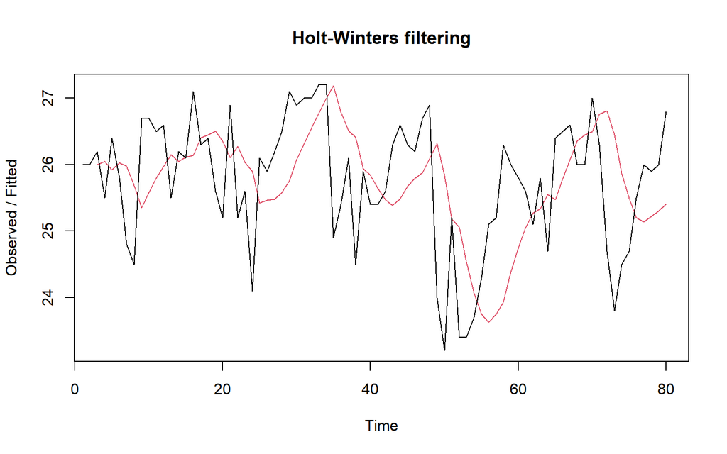

```r
#Lamda=0.2 dan gamma=0.2
des.1<- HoltWinters(train.ts, gamma = FALSE, beta = 0.2, alpha = 0.2)
plot(des.1)
```

```r
#ramalan
ramalandes1<- forecast(des.1, h=20)
ramalandes1
```

```
##     Point Forecast    Lo 80    Hi 80    Lo 95    Hi 95
##  81       25.70965 24.33485 27.08446 23.60707 27.81223
##  82       25.73297 24.31912 27.14681 23.57068 27.89525
##  83       25.75628 24.29097 27.22159 23.51528 27.99728
##  84       25.77959 24.24966 27.30952 23.43977 28.11942
##  85       25.80291 24.19492 27.41090 23.34370 28.26212
##  86       25.82622 24.12680 27.52565 23.22717 28.42527
##  87       25.84954 24.04566 27.65342 23.09075 28.60833
##  88       25.87285 23.95206 27.79365 22.93525 28.81045
##  89       25.89617 23.84665 27.94569 22.76170 29.03064
##  90       25.91948 23.73013 28.10883 22.57116 29.26781
##  91       25.94280 23.60320 28.28239 22.36470 29.52089
##  92       25.96611 23.46654 28.46569 22.14334 29.78888
##  93       25.98943 23.32075 28.65810 21.90803 30.07082
##  94       26.01274 23.16640 28.85908 21.65963 30.36585
##  95       26.03605 23.00399 29.06811 21.39892 30.67319
##  96       26.05937 22.83399 29.28474 21.12658 30.99215
##  97       26.08268 22.65680 29.50857 20.84324 31.32212
##  98       26.10600 22.47277 29.73923 20.54945 31.66255
##  99       26.12931 22.28222 29.97641 20.24569 32.01294
## 100       26.15263 22.08544 30.21982 19.93239 32.37286
```

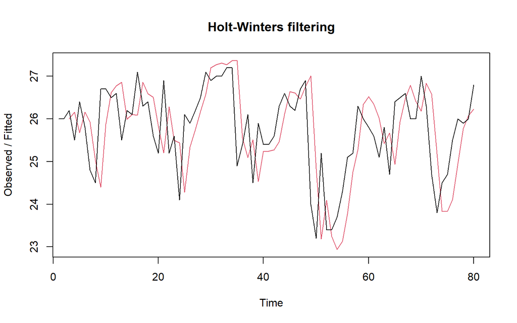

```r
#Lamda=0.6 dan gamma=0.3
des.2<- HoltWinters(train.ts, gamma = FALSE, beta = 0.3, alpha = 0.6)
plot(des.2)
```

```r
#ramalan
ramalandes2<- forecast(des.2, h=20)
ramalandes2
```

```
##     Point Forecast    Lo 80    Hi 80    Lo 95    Hi 95
##  81       26.88080 25.62823 28.13338 24.96516 28.79645
##  82       27.18847 25.59992 28.77702 24.75899 29.61794
##  83       27.49613 25.50379 29.48848 24.44911 30.54316
##  84       27.80380 25.35259 30.25501 24.05500 31.55260
##  85       28.11147 25.15476 31.06818 23.58957 32.63337
##  86       28.41913 24.91595 31.92231 23.06148 33.77678
##  87       28.72680 24.64018 32.81342 22.47686 34.97674
##  88       29.03447 24.33039 33.73854 21.84020 36.22873
##  89       29.34213 23.98885 34.69542 21.15499 37.52927
##  90       29.64980 23.61738 35.68221 20.42402 38.87558
##  91       29.95746 23.21750 36.69743 19.64958 40.26535
##  92       30.26513 22.79046 37.73980 18.83361 41.69665
##  93       30.57280 22.33737 38.80822 17.97780 43.16779
##  94       30.88046 21.85918 39.90174 17.08360 44.67732
##  95       31.18813 21.35674 41.01952 16.15232 46.22394
##  96       31.49580 20.83081 42.16078 15.18510 47.80649
##  97       31.80346 20.28207 43.32485 14.18301 49.42391
##  98       32.11113 19.71115 44.51110 13.14700 51.07525
##  99       32.41879 19.11863 45.71896 12.07795 52.75964
## 100       32.72646 18.50503 46.94789 10.97666 54.47626
```

Selanjutnya jika ingin membandingkan plot data latih dan data uji adalah sebagai berikut.

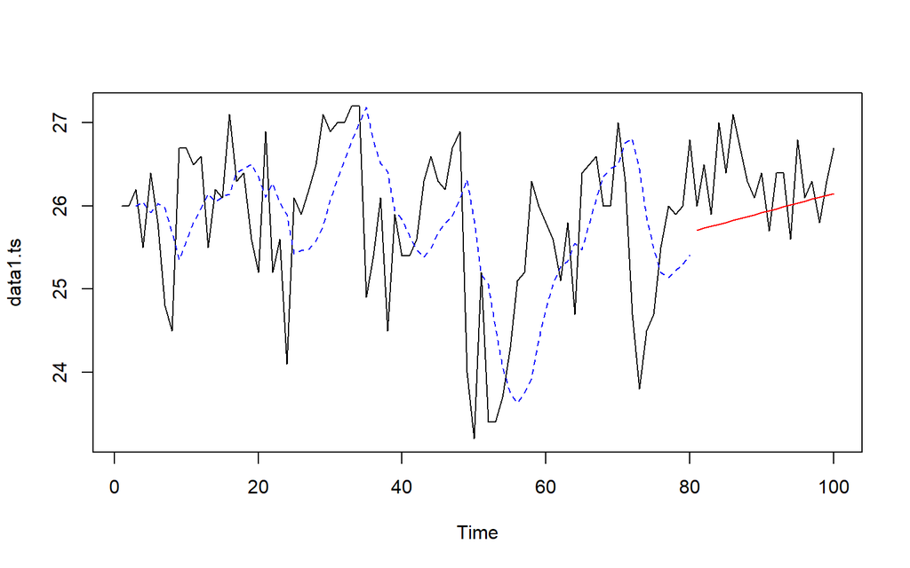

```r
plot(data1.ts)
lines(des.1$fitted[,1], lty=2, col="blue")
lines(ramalandes1$mean, col="red")
```

Untuk mendapatkan nilai parameter optimum dari DES, argumen `alpha` dan `beta` dapat dibuat `NULL` seperti berikut.

```r
#Lamda dan gamma optimum
des.opt<- HoltWinters(train.ts, gamma = FALSE)
des.opt
```

```
## Holt-Winters exponential smoothing with trend and without seasonal component.
##
## Call:
## HoltWinters(x = train.ts, gamma = FALSE)
##
## Smoothing parameters:
##  alpha: 0.615229
##  beta : 0
##  gamma: FALSE
##
## Coefficients:
##      [,1]
## a 26.4646
## b  0.0000
```

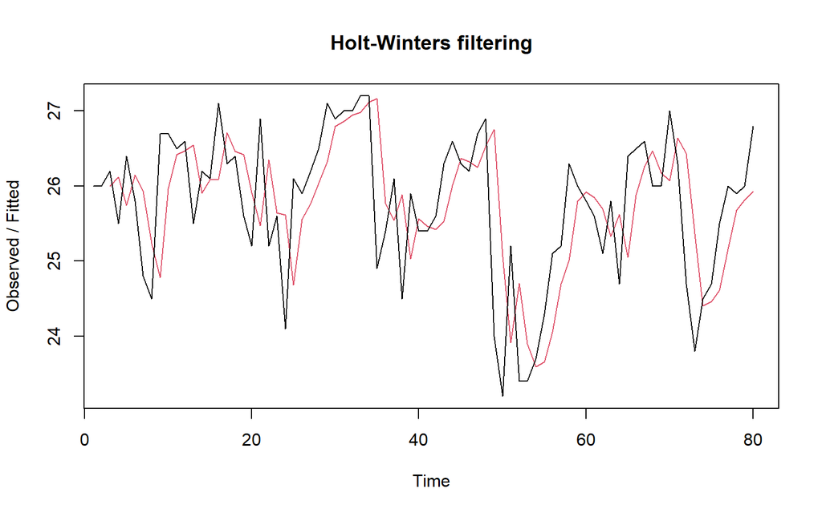

```r
plot(des.opt)
```

```r
#ramalan
ramalandesopt<- forecast(des.opt, h=20)
ramalandesopt
```

```
##     Point Forecast    Lo 80    Hi 80    Lo 95    Hi 95
##  81        26.4646 25.33162 27.59758 24.73186 28.19734
##  82        26.4646 25.13437 27.79483 24.43019 28.49901
##  83        26.4646 24.96281 27.96639 24.16781 28.76139
##  84        26.4646 24.80893 28.12027 23.93247 28.99673
##  85        26.4646 24.66818 28.26101 23.71722 29.21198
##  86        26.4646 24.53769 28.39151 23.51764 29.41155
##  87        26.4646 24.41549 28.51371 23.33076 29.59844
##  88        26.4646 24.30018 28.62902 23.15440 29.77479
##  89        26.4646 24.19071 28.73849 22.98698 29.94222
##  90        26.4646 24.08627 28.84293 22.82726 30.10194
##  91        26.4646 23.98623 28.94297 22.67426 30.25494
##  92        26.4646 23.89007 29.03912 22.52720 30.40200
##  93        26.4646 23.79738 29.13182 22.38544 30.54376
##  94        26.4646 23.70780 29.22139 22.24844 30.68075
##  95        26.4646 23.62105 29.30815 22.11576 30.81344
##  96        26.4646 23.53686 29.39234 21.98701 30.94219
##  97        26.4646 23.45503 29.47417 21.86185 31.06734
##  98        26.4646 23.37536 29.55384 21.74002 31.18918
##  99        26.4646 23.29770 29.63150 21.62124 31.30795
## 100        26.4646 23.22189 29.70730 21.50531 31.42389
```

Selanjutnya akan dilakukan perhitungan akurasi pada data latih maupun data uji dengan ukuran akurasi SSE, MSE dan MAPE.

### Akurasi Data Latih

```r
#Akurasi Data Training
ssedes.train1<-des.1$SSE
msedes.train1<-ssedes.train1/length(train.ts)
sisaandes1<-ramalandes1$residuals
head(sisaandes1)
```

```
## Time Series:
## Start = 1
## End = 6
## Frequency = 1
## [1]         NA         NA  0.2000000 -0.5480000  0.4755200 -0.2246848
```

```r
mapedes.train1 <- sum(abs(sisaandes1[3:length(train.ts)]/train.ts[3:length(train.ts)])
                      *100)/length(train.ts)

akurasides.1 <- matrix(c(ssedes.train1,msedes.train1,mapedes.train1))
row.names(akurasides.1)<- c("SSE", "MSE", "MAPE")
colnames(akurasides.1) <- c("Akurasi lamda=0.2 dan gamma=0.2")
akurasides.1
```

```
##      Akurasi lamda=0.2 dan gamma=0.2
## SSE                        88.617970
## MSE                         1.107725
## MAPE                        3.319796
```

```r
ssedes.train2<-des.2$SSE
msedes.train2<-ssedes.train2/length(train.ts)
sisaandes2<-ramalandes2$residuals
head(sisaandes2)
```

```
## Time Series:
## Start = 1
## End = 6
## Frequency = 1
## [1]         NA         NA  0.2000000 -0.6560000  0.7196800 -0.3595904
```

```r
mapedes.train2 <- sum(abs(sisaandes2[3:length(train.ts)]/train.ts[3:length(train.ts)])
                      *100)/length(train.ts)

akurasides.2 <- matrix(c(ssedes.train2,msedes.train2,mapedes.train2))
row.names(akurasides.2)<- c("SSE", "MSE", "MAPE")
colnames(akurasides.2) <- c("Akurasi lamda=0.6 dan gamma=0.3")
akurasides.2
```

```
##      Akurasi lamda=0.6 dan gamma=0.3
## SSE                       73.5946816
## MSE                        0.9199335
## MAPE                       2.9008117
```

Hasil akurasi dari data latih didapatkan skenario 2 dengan lamda=0.6 dan gamma=0.3 memiliki hasil yang lebih baik. Namun untuk kedua skenario dapat dikategorikan peramalan sangat baik berdasarkan nilai MAPE-nya.

### Akurasi Data Uji

```r
#Akurasi Data Testing
selisihdes1<-ramalandes1$mean-testing$Rata_Suhu
selisihdes1
```

```
## Time Series:
## Start = 81
## End = 100
## Frequency = 1
##  [1] -0.29034922 -0.76703470 -0.14372017 -1.22040565 -0.59709113 -1.27377661
##  [7] -0.85046208 -0.42714756 -0.20383304 -0.48051851  0.24279601 -0.43388947
## [13] -0.41057495  0.41273958 -0.76394590 -0.04063138 -0.21731686  0.30599767
## [19] -0.17068781 -0.54737329
```

```r
SSEtestingdes1<-sum(selisihdes1^2)
MSEtestingdes1<-SSEtestingdes1/length(testing$Rata_Suhu)
MAPEtestingdes1<-sum(abs(selisihdes1/testing$Rata_Suhu)*100)/length(testing$Rata_Suhu)

selisihdes2<-ramalandes2$mean-testing$Rata_Suhu
selisihdes2
```

```
## Time Series:
## Start = 81
## End = 100
## Frequency = 1
##  [1] 0.8808020 0.6884682 1.5961344 0.8038006 1.7114668 1.3191330 2.0267992
##  [8] 2.7344654 3.2421316 3.2497978 4.2574640 3.8651302 4.1727964 5.2804626
## [15] 4.3881288 5.3957950 5.5034612 6.3111274 6.1187936 6.0264598
```

```r
SSEtestingdes2<-sum(selisihdes2^2)
MSEtestingdes2<-SSEtestingdes2/length(testing$Rata_Suhu)
MAPEtestingdes2<-sum(abs(selisihdes2/testing$Rata_Suhu)*100)/length(testing$Rata_Suhu)

selisihdesopt<-ramalandesopt$mean-testing$Rata_Suhu
selisihdesopt
```

```
## Time Series:
## Start = 81
## End = 100
## Frequency = 1
##  [1]  0.4645982 -0.0354018  0.5645982 -0.5354018  0.0645982 -0.6354018
##  [7] -0.2354018  0.1645982  0.3645982  0.0645982  0.7645982  0.0645982
## [13]  0.0645982  0.8645982 -0.3354018  0.3645982  0.1645982  0.6645982
## [19]  0.1645982 -0.2354018
```

```r
SSEtestingdesopt<-sum(selisihdesopt^2)
MSEtestingdesopt<-SSEtestingdesopt/length(testing$Rata_Suhu)
MAPEtestingdesopt<-sum(abs(selisihdesopt/testing$Rata_Suhu)*100)/length(testing$Rata_Suhu)

akurasitestingdes <-
  matrix(c(SSEtestingdes1,MSEtestingdes1,MAPEtestingdes1,SSEtestingdes2,MSEtestingdes2,
           MAPEtestingdes2,SSEtestingdesopt,MSEtestingdesopt,MAPEtestingdesopt),
         nrow=3,ncol=3)
row.names(akurasitestingdes)<- c("SSE", "MSE", "MAPE")
colnames(akurasitestingdes) <- c("des ske1","des ske2","des opt")
akurasitestingdes
```

```
##       des ske1  des ske2   des opt
## SSE  6.9809147 312.37788 3.5872532
## MSE  0.3490457  15.61889 0.1793627
## MAPE 1.8465994  13.25532 1.3010705
```

### Perbandingan SES dan DES

```r
MSEfull <-
  matrix(c(MSEtesting1,MSEtesting2,MSEtestingopt,MSEtestingdes1,MSEtestingdes2,
           MSEtestingdesopt),nrow=3,ncol=2)
row.names(MSEfull)<- c("ske 1", "ske 2", "ske opt")
colnames(MSEfull) <- c("ses","des")
MSEfull
```

```
##               ses        des
## ske 1   0.4054913  0.3490457
## ske 2   0.2093813 15.6188942
## ske opt 0.1793621  0.1793627
```

# Seasonal Smoothing

Selanjutnya melakukan pembagian data dan mengubahnya menjadi data deret waktu.

```r
#membagi data menjadi training dan testing
training<-data1[1:80,2]
testing<-data1[81:100,2]
training.ts<-ts(training, frequency = 13)
testing.ts<-ts(testing, frequency = 13)
```

Kemudian akan dilakukan eskplorasi dengan plot data deret waktu sebagai berikut.

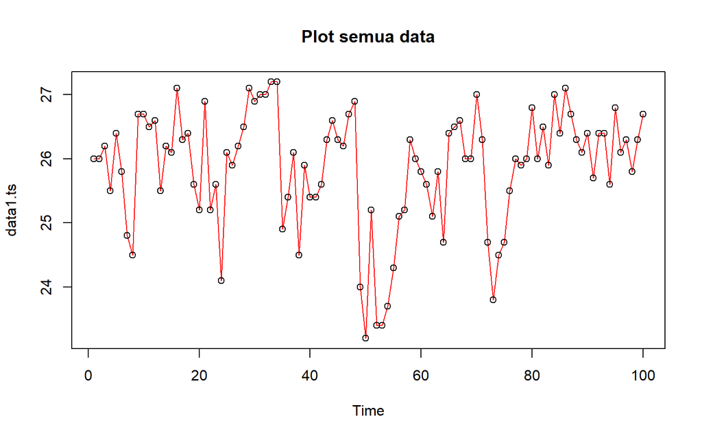

```r
#Membuat plot time series
plot(data1.ts, col="red",main="Plot semua data")
points(data1.ts)
```

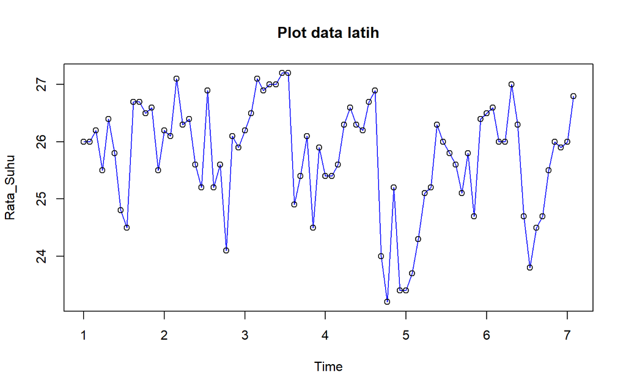

```r
plot(training.ts, col="blue",main="Plot data latih")
points(training.ts)
```

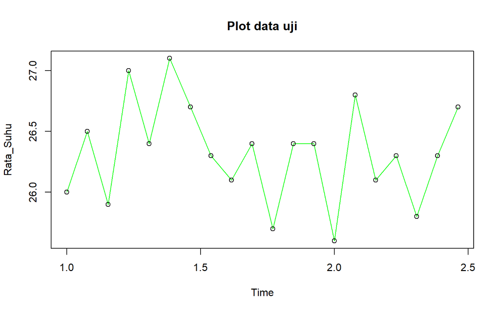

```r
plot(testing.ts, col="green",main="Plot data uji")
points(testing.ts)
```

Metode Holt-Winter untuk peramalan data musiman menggunakan tiga persamaan pemulusan yang terdiri atas persamaan untuk level $(L_t)$, trend $(B_t)$, dan komponen seasonal / musiman $(S_t)$ dengan parameter pemulusan berupa $\alpha$, $\beta$, dan $\gamma$. Metode Holt-Winter musiman terbagi menjadi dua, yaitu metode aditif dan metode multiplikatif. Perbedaan persamaan dan contoh datanya adalah sebagai berikut.

$$L_t = \alpha(Y_t - S_{t-s}) +
(1-\alpha)(L_{t-1} + B_{t-1})$$

$$B_t = \beta(L_t - L_{t-1}) +
(1-\beta)B_{t-1}$$
$$S_t = \gamma(Y_t
- L_t) + (1-\gamma)S_{t-s}$$

[figure not shown]

Pemulusan data musiman dengan metode Winter dilakukan menggunakan fungsi `HoltWinters()` dengan memasukkan argumen tambahan, yaitu `gamma()` dan `seasonal()` . Arguman `seasonal()` diinisialisasi menyesuaikan jenis musiman, aditif atau multiplikatif.

## Winter Aditif

Perhitungan dengan model aditif dilakukan jika plot data asli menunjukkan fluktuasi musiman yang relatif stabil (konstan).

### Pemulusan

```r
#Pemulusan dengan winter aditif
winter1 <- HoltWinters(training.ts,alpha=0.2,beta=0.1,gamma=0.1,seasonal = "additive")
winter1$fitted
```

```
## Time Series:
## Start = c(2, 1)
## End = c(7, 2)
## Frequency = 13
##              xhat    level         trend       season
## 2.000000 26.08540 26.04227 -0.0009467456  0.044082840
## 2.076923 25.82505 26.06424  0.0013452240 -0.240532544
## 2.153846 27.00227 26.12057  0.0068442029  0.874852071
## 2.230769 26.31523 26.14696  0.0087988096  0.159467456
## 2.307692 26.60529 26.15272  0.0084942111  0.444082840
## 2.384615 25.80708 26.12015  0.0043883404 -0.317455621
## 2.461538 25.11591 26.08312  0.0002466462 -0.967455621
## 2.538462 24.60004 26.10019  0.0019283580 -1.502071006
## 2.615385 27.30027 26.56211  0.0479274679  0.690236686
## 2.692308 26.81691 26.18998  0.0059220527  0.621005917
## 2.769231 26.29357 25.95252 -0.0184161052  0.359467456
## 2.846154 25.89257 25.49539 -0.0622875402  0.459467456
## 2.923077 24.79130 25.47459 -0.0581389373 -0.625147929
## 3.000000 25.65547 25.63819 -0.0359649686  0.053250719
## 3.076923 25.46752 25.71113 -0.0250744672 -0.218536629
## 3.153846 26.77080 25.89255 -0.0044248298  0.882670498
## 3.230769 26.11438 25.95397  0.0021592341  0.158249062
## 3.307692 26.55878 26.11325  0.0178717294  0.427659357
## 3.384615 25.91204 26.21937  0.0266960851 -0.334022398
## 3.461538 25.55138 26.46365  0.0484552830 -0.960728774
## 3.538462 25.60519 26.84183  0.0814276632 -1.318074566
## 3.615385 27.87776 27.24222  0.1133239300  0.522215025
## 3.692308 27.33742 26.76000  0.0537686730  0.523653286
## 3.769231 26.62528 26.42628  0.0150203287  0.183981716
## 3.846154 26.81682 26.33624  0.0045146781  0.476061867
## 3.923077 25.29912 25.87739 -0.0418217390 -0.536452054
## 4.000000 26.02276 25.95575 -0.0298041595  0.096812724
## 4.076923 25.62320 25.80139 -0.0422593082 -0.135938079
## 4.153846 26.57678 25.71449 -0.0467232250  0.909006754
## 4.230769 25.62726 25.47242 -0.0662587905  0.221099043
## 4.307692 25.95086 25.54071 -0.0528039129  0.462956780
## 4.384615 25.33092 25.61773 -0.0398210874 -0.246985606
## 4.461538 24.92245 25.77172 -0.0204395574 -0.828839253
## 4.538462 24.82142 26.00680  0.0051115306 -1.190489499
## 4.615385 26.71430 26.38762  0.0426831753  0.283993997
```

[output cut: 17 more lines]

```
## 6.000000 25.54213 25.56538  0.0441526140 -0.067403802
## 6.076923 25.66954 25.80111  0.0633099993 -0.194880118
## 6.153846 26.91084 26.05051  0.0819192339  0.778411966
## 6.230769 26.36763 25.95026  0.0637023952  0.353670489
## 6.307692 26.57414 25.94044  0.0563497059  0.577355311
## 6.384615 26.17950 26.08196  0.0648668639  0.032676000
## 6.461538 25.69922 26.17092  0.0672768393 -0.538981291
## 6.538462 25.20627 26.03836  0.0472924286 -0.879376474
## 6.615385 26.12635 25.80440  0.0191669551  0.302788443
## 6.692308 25.59733 25.49829 -0.0133600611  0.112396462
## 6.769231 25.23902 25.30547 -0.0313066332 -0.035135712
## 6.846154 25.48483 25.32635 -0.0260871148  0.184559227
## 6.923077 24.94184 25.40330 -0.0157836565 -0.445683062
## 7.000000 25.59176 25.57915  0.0033796290  0.009225739
## 7.076923 25.55528 25.66418  0.0115444888 -0.120443180
```

```r
xhat1 <- winter1$fitted[,2]

winter1.opt<- HoltWinters(training.ts, alpha= NULL,  beta = NULL, gamma = NULL, seasonal = "additive")
winter1.opt
```

```
## Holt-Winters exponential smoothing with trend and additive seasonal component.
##
## Call:
## HoltWinters(x = training.ts, alpha = NULL, beta = NULL, gamma = NULL,     seasonal = "additive")
##
## Smoothing parameters:
##  alpha: 0.4708509
##  beta : 0
##  gamma: 0.4841576
##
## Coefficients:
##              [,1]
## a   26.2867510693
## b   -0.0009467456
## s1   0.3880797430
## s2   0.5815685061
## s3   0.8940107242
## s4   0.4758542836
## s5  -0.3984617354
## s6  -0.6788624790
## s7  -0.4658348218
## s8  -0.6934764092
## s9  -0.3119480853
## s10 -0.0207837613
## s11  0.0355890337
## s12  0.0703714069
## s13  0.2914326194
```

```r
winter1.opt$fitted
```

```
## Time Series:
## Start = c(2, 1)
## End = c(7, 2)
## Frequency = 13
##              xhat    level         trend       season
## 2.000000 26.08540 26.04227 -0.0009467456  0.044082840
## 2.076923 25.85380 26.09528 -0.0009467456 -0.240532544
## 2.153846 27.08416 26.21026 -0.0009467456  0.874852071
## 2.230769 26.37529 26.21677 -0.0009467456  0.159467456
## 2.307692 26.62351 26.18037 -0.0009467456  0.444082840
## 2.384615 25.75578 26.07419 -0.0009467456 -0.317455621
## 2.461538 25.03149 25.99989 -0.0009467456 -0.967455621
## 2.538462 24.57527 26.07829 -0.0009467456 -1.502071006
## 2.615385 27.86123 27.17194 -0.0009467456  0.690236686
## 2.692308 26.53801 25.91795 -0.0009467456  0.621005917
## 2.769231 25.83386 25.47534 -0.0009467456  0.359467456
## 2.846154 25.11653 24.65800 -0.0009467456  0.459467456
## 2.923077 24.49403 25.12013 -0.0009467456 -0.625147929
## 3.000000 25.85368 25.78118 -0.0009467456  0.073442005
## 3.076923 25.76490 25.94330 -0.0009467456 -0.177457713
## 3.153846 27.16644 26.28848 -0.0009467456  0.878910046
## 3.230769 26.39548 26.25625 -0.0009467456  0.140179529
## 3.307692 26.87873 26.49285 -0.0009467456  0.386822293
## 3.384615 26.19070 26.54901 -0.0009467456 -0.357365965
## 3.461538 26.00389 26.92912 -0.0009467456 -0.924283703
## 3.538462 26.58392 27.49136 -0.0009467456 -0.906494441
## 3.615385 27.78800 27.78050 -0.0009467456  0.008451627
## 3.692308 26.79948 26.41973 -0.0009467456  0.380695456
## 3.769231 25.67416 25.75984 -0.0009467456 -0.084733482
## 3.846154 26.66988 25.95940 -0.0009467456  0.711425450
## 3.923077 24.67087 24.93676 -0.0009467456 -0.264951016
## 4.000000 25.67578 25.51456 -0.0009467456  0.162167058
## 4.076923 25.39368 25.38376 -0.0009467456  0.010869487
## 4.153846 26.24673 25.38579 -0.0009467456  0.861888196
## 4.230769 25.34881 25.08033 -0.0009467456  0.269433199
## 4.307692 25.94419 25.52725 -0.0009467456  0.417890669
## 4.384615 25.68411 25.83509 -0.0009467456 -0.150028850
## 4.461538 25.50534 26.12413 -0.0009467456 -0.617851036
## 4.538462 25.70066 26.45027 -0.0009467456 -0.748660768
## 4.615385 26.18748 26.91986 -0.0009467456 -0.731430367
```

[output cut: 17 more lines]

```
## 6.000000 25.88381 25.99530 -0.0009467456 -0.110545201
## 6.076923 26.28646 26.28449 -0.0009467456  0.002913945
## 6.153846 27.10016 26.43118 -0.0009467456  0.669931378
## 6.230769 26.66259 25.91222 -0.0009467456  0.751318102
## 6.307692 26.31750 25.59929 -0.0009467456  0.719161102
## 6.384615 26.42719 25.91970 -0.0009467456  0.508439111
## 6.461538 25.72104 25.85886 -0.0009467456 -0.136881143
## 6.538462 25.00643 25.37716 -0.0009467456 -0.369785632
## 6.615385 24.28675 24.80817 -0.0009467456 -0.520467028
## 6.692308 24.04554 24.90763 -0.0009467456 -0.861144574
## 6.769231 24.69595 25.21484 -0.0009467456 -0.517938976
## 6.846154 25.42290 25.59248 -0.0009467456 -0.168632667
## 6.923077 25.89718 25.86326 -0.0009467456  0.034866222
## 7.000000 25.91001 25.86364 -0.0009467456  0.047317014
## 7.076923 25.98736 25.90507 -0.0009467456  0.083241029
```

```r
xhat1.opt <- winter1.opt$fitted[,2]
```

### Peramalan

```r
#Forecast
forecast1 <- predict(winter1, n.ahead = 20)
forecast1.opt <- predict(winter1.opt, n.ahead = 20)
```

### Plot Deret Waktu

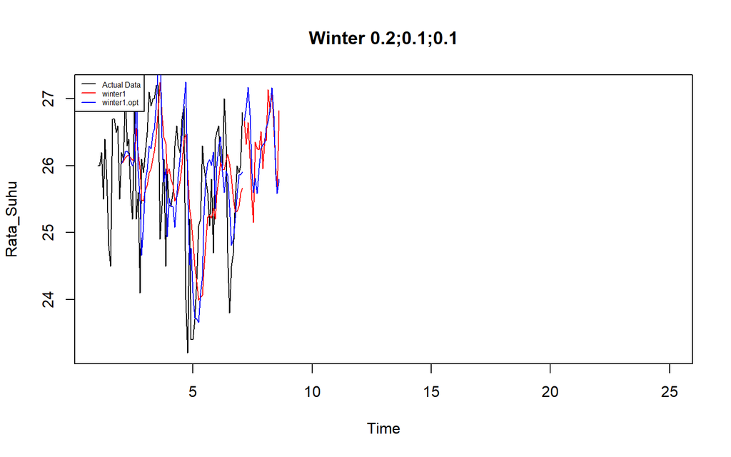

```r
#Plot time series
plot(training.ts,main="Winter 0.2;0.1;0.1",type="l",col="black",
     xlim=c(1,25),pch=12)
lines(xhat1,type="l",col="red")
lines(xhat1.opt,type="l",col="blue")
lines(forecast1,type="l",col="red")
lines(forecast1.opt,type="l",col="blue")
legend("topleft",c("Actual Data",expression(paste(winter1)),
                   expression(paste(winter1.opt))),cex=0.5,
       col=c("black","red","blue"),lty=1)
```

### Akurasi Data Latih

```r
#Akurasi data training
SSE1<-winter1$SSE
MSE1<-winter1$SSE/length(training.ts)
RMSE1<-sqrt(MSE1)
akurasi1 <- matrix(c(SSE1,MSE1,RMSE1))
row.names(akurasi1)<- c("SSE", "MSE", "RMSE")
colnames(akurasi1) <- c("Akurasi")
akurasi1
```

```
##         Akurasi
## SSE  108.618804
## MSE    1.357735
## RMSE   1.165219
```

```r
SSE1.opt<-winter1.opt$SSE
MSE1.opt<-winter1.opt$SSE/length(training.ts)
RMSE1.opt<-sqrt(MSE1.opt)
akurasi1.opt <- matrix(c(SSE1.opt,MSE1.opt,RMSE1.opt))
row.names(akurasi1.opt)<- c("SSE1.opt", "MSE1.opt", "RMSE1.opt")
colnames(akurasi1.opt) <- c("Akurasi")
akurasi1.opt
```

```
##             Akurasi
## SSE1.opt  82.943565
## MSE1.opt   1.036795
## RMSE1.opt  1.018231
```

```r
akurasi1.train = data.frame(Model_Winter = c("Winter Aditif","Winter Aditif Optimal"),
                            Nilai_SSE=c(SSE1,SSE1.opt),
                            Nilai_MSE=c(MSE1,MSE1.opt),Nilai_RMSE=c(RMSE1,RMSE1.opt))
akurasi1.train
```

```
##            Model_Winter Nilai_SSE Nilai_MSE Nilai_RMSE
## 1         Winter Aditif 108.61880  1.357735   1.165219
## 2 Winter Aditif Optimal  82.94357  1.036795   1.018231
```

### Akurasi Data Uji

```r
#Akurasi Data Testing
forecast1<-data.frame(forecast1)
testing.ts<-data.frame(testing.ts)
selisih1<-forecast1-testing.ts
SSEtesting1<-sum(selisih1^2)
MSEtesting1<-SSEtesting1/length(testing.ts)

forecast1.opt<-data.frame(forecast1.opt)
selisih1.opt<-forecast1.opt-testing.ts
SSEtesting1.opt<-sum(selisih1.opt^2)
MSEtesting1.opt<-SSEtesting1.opt/length(testing.ts)
```

```r
akurasi_testing <- data.frame(
  Model = c("Winter Aditif", "Winter Aditif Optimum"),
  SSE   = c(SSEtesting1, SSEtesting1.opt),
  MSE   = c(MSEtesting1, MSEtesting1.opt)
)

akurasi_testing
```

```
##                   Model      SSE      MSE
## 1         Winter Aditif 10.66000 10.66000
## 2 Winter Aditif Optimum 10.30836 10.30836
```

## Winter Multiplikatif

Model multiplikatif digunakan cocok digunakan jika plot data asli menunjukkan fluktuasi musiman yang bervariasi.

### Pemulusan

```r
#Pemulusan dengan winter multiplikatif
winter2 <- HoltWinters(training.ts,alpha=0.2,beta=0.1,gamma=0.3,seasonal = "multiplicative")
winter2$fitted
```

```
## Time Series:
## Start = c(2, 1)
## End = c(7, 2)
## Frequency = 13
##              xhat    level         trend    season
## 2.000000 26.08588 26.04227 -0.0009467456 1.0017113
## 2.076923 25.82775 26.06410  0.0013316943 0.9908811
## 2.153846 26.99936 26.12039  0.0068268445 1.0333810
## 2.230769 26.31573 26.14669  0.0087745327 1.0061275
## 2.307692 26.60945 26.15234  0.0084618027 1.0171499
## 2.384615 25.80508 26.11961  0.0043433505 0.9877936
## 2.461538 25.11203 26.08244  0.0001910899 0.9627876
## 2.538462 24.59593 26.10090  0.0020185153 0.9422673
## 2.615385 27.35092 26.59197  0.0509233782 1.0265748
## 2.692308 26.85837 26.22384  0.0090185746 1.0238446
## 2.769231 26.32934 25.98705 -0.0155627456 1.0137787
## 2.846154 25.92055 25.53168 -0.0595435123 1.0176042
## 2.923077 24.84306 25.50740 -0.0560166453 0.9760984
## 3.000000 25.70439 25.66795 -0.0343601735 1.0027621
## 3.076923 25.53785 25.73244 -0.0244753448 0.9933827
## 3.153846 26.78495 25.90168 -0.0051040739 1.0343047
## 3.230769 26.11379 25.95749  0.0009880037 1.0059831
## 3.307692 26.52927 26.11479  0.0166185947 1.0152253
## 3.384615 25.88008 26.22414  0.0258920962 0.9859066
## 3.461538 25.56020 26.47722  0.0486106805 0.9635965
## 3.538462 25.95340 26.86618  0.0826457513 0.9630622
## 3.615385 27.50444 27.20771  0.1085340880 1.0068896
## 3.692308 27.18398 26.79892  0.0568016592 1.0122230
## 3.769231 26.33441 26.50323  0.0215529281 0.9928227
## 3.846154 27.00554 26.47757  0.0168308368 1.0192927
## 3.923077 25.60636 26.00277 -0.0323315733 0.9859810
## 4.000000 26.19565 26.03000 -0.0263752952 1.0073845
## 4.076923 25.86278 25.84566 -0.0421716821 1.0022978
## 4.153846 26.61474 25.71115 -0.0514061422 1.0372176
## 4.230769 25.72851 25.46408 -0.0709726638 1.0132085
## 4.307692 25.94327 25.50591 -0.0596918511 1.0195334
## 4.384615 25.42761 25.57505 -0.0468089479 0.9960580
## 4.461538 25.11558 25.70341 -0.0292920391 0.9782451
## 4.538462 25.21711 25.89582 -0.0071213229 0.9740585
## 4.615385 25.78565 26.19318  0.0233262798 0.9835653
```

[output cut: 17 more lines]

```
## 6.000000 25.50002 25.81880  0.0660983867 0.9851308
## 6.076923 25.92795 26.08792  0.0863999335 0.9905873
## 6.153846 26.98699 26.31001  0.0999687151 1.0218482
## 6.230769 26.97011 26.21680  0.0806510462 1.0255791
## 6.307692 27.00601 26.10827  0.0617326674 1.0319453
## 6.384615 26.91870 26.16883  0.0616162751 1.0262388
## 6.461538 26.35001 26.10987  0.0495585614 1.0072854
## 6.538462 25.88138 25.83182  0.0167969702 1.0012676
## 6.615385 25.43956 25.43286 -0.0247778877 1.0012386
## 6.692308 24.67175 25.22041 -0.0435457979 0.9799376
## 6.769231 24.62053 25.18263 -0.0429693050 0.9793503
## 6.846154 24.97798 25.31926 -0.0250090687 0.9874964
## 6.923077 25.18207 25.50124 -0.0043098747 0.9876509
## 7.000000 25.50710 25.64231  0.0102283087 0.9943304
## 7.076923 25.68724 25.75168  0.0201424849 0.9967178
```

```r
xhat2 <- winter2$fitted[,2]

winter2.opt<- HoltWinters(training.ts, alpha= NULL,  beta = NULL, gamma = NULL, seasonal = "multiplicative")
winter2.opt$fitted
```

```
## Time Series:
## Start = c(2, 1)
## End = c(7, 2)
## Frequency = 13
##              xhat    level         trend    season
## 2.000000 26.08588 26.04227 -0.0009467456 1.0017113
## 2.076923 25.85387 26.09275 -0.0009467456 0.9908811
## 2.153846 27.07767 26.20394 -0.0009467456 1.0333810
## 2.230769 26.37241 26.21275 -0.0009467456 1.0061275
## 2.307692 26.62732 26.17931 -0.0009467456 1.0171499
## 2.384615 25.75822 26.07747 -0.0009467456 0.9877936
## 2.461538 25.03562 26.00421 -0.0009467456 0.9627876
## 2.538462 24.57376 26.08034 -0.0009467456 0.9422673
## 2.615385 27.91562 27.19392 -0.0009467456 1.0265748
## 2.692308 26.61770 25.99874 -0.0009467456 1.0238446
## 2.769231 25.90013 25.54906 -0.0009467456 1.0137787
## 2.846154 25.18117 24.74649 -0.0009467456 1.0176042
## 2.923077 24.55105 25.15317 -0.0009467456 0.9760984
## 3.000000 25.84832 25.77612 -0.0009467456 1.0028379
## 3.076923 25.75881 25.93349 -0.0009467456 0.9933007
## 3.153846 27.15109 26.26941 -0.0009467456 1.0336004
## 3.230769 26.38732 26.24615 -0.0009467456 1.0054150
## 3.307692 26.86904 26.47540 -0.0009467456 1.0149044
## 3.384615 26.16632 26.53271 -0.0009467456 0.9862262
## 3.461538 25.95466 26.91338 -0.0009467456 0.9644112
## 3.538462 26.51299 27.49539 -0.0009467456 0.9643033
## 3.615385 27.80589 27.81608 -0.0009467456 0.9996677
## 3.692308 26.86187 26.50283 -0.0009467456 1.0135834
## 3.769231 25.72161 25.85077 -0.0009467456 0.9950399
## 3.846154 26.72348 26.02150 -0.0009467456 1.0270144
## 3.923077 24.78127 25.04317 -0.0009467456 0.9895797
## 4.000000 25.71341 25.55259 -0.0009467456 1.0063312
## 4.076923 25.42455 25.41104 -0.0009467456 1.0005689
## 4.153846 26.23872 25.39902 -0.0009467456 1.0330989
## 4.230769 25.37932 25.11896 -0.0009467456 1.0104033
## 4.307692 25.94137 25.52937 -0.0009467456 1.0161758
## 4.384615 25.67048 25.82103 -0.0009467456 0.9942058
## 4.461538 25.48053 26.10594 -0.0009467456 0.9760788
## 4.538462 25.66130 26.43776 -0.0009467456 0.9706657
## 4.615385 26.14969 26.91990 -0.0009467456 0.9714229
```

[output cut: 17 more lines]

```
## 6.000000 25.90013 26.06109 -0.0009467456 0.9938596
## 6.076923 26.31081 26.33263 -0.0009467456 0.9992072
## 6.153846 27.14143 26.46234 -0.0009467456 1.0256992
## 6.230769 26.72449 25.95901 -0.0009467456 1.0295258
## 6.307692 26.36700 25.64037 -0.0009467456 1.0283774
## 6.384615 26.43973 25.91730 -0.0009467456 1.0201947
## 6.461538 25.72654 25.85452 -0.0009467456 0.9950861
## 6.538462 25.02612 25.38786 -0.0009467456 0.9857884
## 6.615385 24.32596 24.82540 -0.0009467456 0.9799193
## 6.692308 24.04604 24.90463 -0.0009467456 0.9655615
## 6.769231 24.62486 25.20945 -0.0009467456 0.9768474
## 6.846154 25.37492 25.61295 -0.0009467456 0.9907435
## 6.923077 25.85137 25.89683 -0.0009467456 0.9982812
## 7.000000 25.90987 25.91787 -0.0009467456 0.9997279
## 7.076923 26.00917 25.95762 -0.0009467456 1.0020224
```

```r
xhat2.opt <- winter2.opt$fitted[,2]
```